# 1. Project Background & Study Objectives

This research is to further learn the customer data, study the pattern of the customers' churn rate, apply machine learning methods to train the prediction model, test the model and conduct sales simulation by apply the chosen model.  
There are four datasets in total for this study. All the dataset are a real dataset from a Telecommunication company. For the study purposes, all the sensitive information has been removed or replaced from the dataset.

The goal and objectives of this study are to answer the following questions:

##### 1) How to define the Churn Rate;

##### 2) What are the factors relavant to Churn Rate;

##### 3) How to define the time window when customer churn happening;

##### 4) How to define the benefits

##### 5) What's the effects of the training models;

##### 6) Simulation of Sales and find out ways to reduce customer churn rate.

# 2. Methodologies

#### The methods and key steps of this study will include:

##### 1) Data Feature Engineering

##### 2) Exploratory Analysis on the Dataset

##### 3) Application of Derivative Indicators

##### 4) Cluster Analysis using Kmeans and Birch

##### 5) Generating Rules Set using Decision Tree

##### 6) Obtaining Churn Scores by Neural Networks

##### 7) Application of Trained Models for Sales Simulation

# 3. Python Codes and Outputs

## 3.1 Exploratory Analysis

### 3.1.1 Understand and Prepare the Dataset

##### Learnings from the Original Dataset

```python
import copy
import random
import numpy as np
import pandas as pd

import datetime
import time
```

```python
from matplotlib import pyplot as plt
import seaborn as sns
```

```python
dfcustcall = pd.read_csv("C:\\Users\\Elizabeth\\Desktop\\Study\\python\\TeleData\\custcall.csv")
dfcustinfo = pd.read_csv("C:\\Users\\Elizabeth\\Desktop\\Study\\python\\TeleData\\custinfo.csv", encoding = "GBK")
dftariff = pd.read_csv("C:\\Users\\Elizabeth\\Desktop\\Study\\python\\TeleData\\tariff.csv")
dfchurn = pd.read_csv("C:\\Users\\Elizabeth\\Desktop\\Study\\python\\TeleData\\churn.csv")
```

```python
dfcustcall.head()
```

|  | Customer_ID | Peak_calls | Peak_mins | OffPeak_calls | OffPeak_mins | Weekend_calls | Weekend_mins | International_mins | Nat_call_cost | month |
| --- | --- | --- | --- | --- | --- | --- | --- | --- | --- | --- |
| 0 | K100130 | 12 | 10.587465 | 5 | 4.479312 | 0 | 0.000000 | 4.381410 | 0 | 4 |
| 1 | K100130 | 14 | 11.530076 | 7 | 4.878109 | 1 | 3.045756 | 4.771490 | 0 | 6 |
| 2 | K100130 | 10 | 9.109470 | 4 | 3.854007 | 0 | 0.000000 | 3.769771 | 0 | 1 |
| 3 | K100130 | 12 | 10.530956 | 5 | 4.455404 | 0 | 0.000000 | 4.358024 | 0 | 3 |
| 4 | K100130 | 11 | 9.507319 | 4 | 4.022327 | 0 | 0.000000 | 3.934413 | 0 | 2 |

```python
dfana = pd.DataFrame({'xvar' : dfcustinfo.Age, 'yvar' : dfchurn.Churn})
dfana.head()
```

|  | xvar | yvar |
| --- | --- | --- |
| 0 | 45 | 1 |
| 1 | 30 | 1 |
| 2 | 37 | 1 |
| 3 | 44 | 0 |
| 4 | 27 | 1 |

```python
vname = "xvar"
yvar = "yvar"
```

```python
dfana[vname].describe(percentiles = [.0, .05, .25, .5, .75, .95, 1.])
```

```
count    18560.000000
mean        31.507489
std         12.847678
min         12.000000
0%          12.000000
5%          14.000000
25%         22.000000
50%         30.000000
75%         39.000000
95%         56.000000
100%        82.000000
max         82.000000
Name: xvar, dtype: float64
```

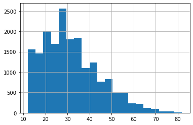

```python
dfana[vname].hist(bins = 20)
```

```python
dfana.groupby(yvar)[vname].describe(percentiles=[.0, .05, .25, .5, .75, .95, 1.])
```

| yvar | count | mean | std | min | 0% | 5% | 25% | 50% | 75% | 95% | 100% | max |
| --- | --- | --- | --- | --- | --- | --- | --- | --- | --- | --- | --- | --- |
| 0 | 17056.0 | 31.814904 | 12.848536 | 12.0 | 12.0 | 14.0 | 22.0 | 30.0 | 40.0 | 56.0 | 82.0 | 82.0 |
| 1 | 1504.0 | 28.021277 | 12.316175 | 12.0 | 12.0 | 13.0 | 18.0 | 25.0 | 35.0 | 53.0 | 81.0 | 81.0 |

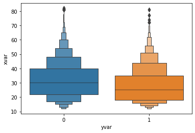

```python
sns.boxenplot(x = dfana[yvar], y = dfana[vname])
```

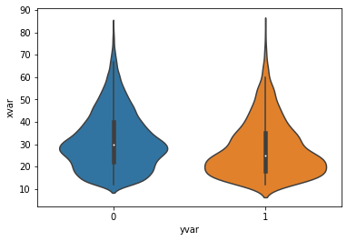

```python
sns.violinplot(x = dfana[yvar], y = dfana[vname])
```

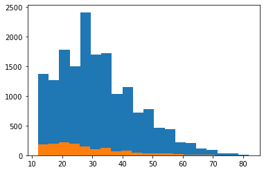

```python
for i in set(dfana[yvar]):
    plt.hist(dfana[vname][dfana[yvar] == i], bins = 20)
```

```python
# Generate bar chart by group
def M_GphDes(x, y, type = '', printdata = True):

    if type == '%':
        tmpdf = pd.crosstab(index = y, columns = x, normalize = "columns")
    else:
        tmpdf = pd.crosstab(index = y, columns = x)

    if printdata:
        print(tmpdf.T)

    colorstep0 = 1/len(tmpdf.index)
    for i in range(len(tmpdf.index)):
        if i == 0:
            colorstep = colorstep0 / 2 # Avoid all blank bar
            sns.barplot(data = tmpdf.loc[[tmpdf.index[i]]],
                        color = str(colorstep), label = tmpdf.index[i])
            base = tmpdf.loc[tmpdf.index[i]]
        else:
            sns.barplot(data = tmpdf.loc[[tmpdf.index[i]]],
                        color = str(colorstep), bottom = base, label = tmpdf.index[i])
            base = base + tmpdf.loc[tmpdf.index[i]]
        colorstep = colorstep + colorstep0
    plt.xticks(rotation = 'vertical') #  Applied matplotlib.text
    plt.legend()
    plt.show()
```

```python
bin = pd.cut(dfana[vname], bins = 20)
```

```
yvar              0    1
xvar
(11.93, 15.5]  1368  183
(15.5, 19.0]   1700  248
(19.0, 22.5]   1346  172
(22.5, 26.0]   2087  234
(26.0, 29.5]   1824  108
(29.5, 33.0]   2161  141
(33.0, 36.5]   1255   84
(36.5, 40.0]   1377   87
(40.0, 43.5]    810   58
(43.5, 47.0]    946   60
(47.0, 50.5]    560   33
(50.5, 54.0]    586   37
(54.0, 57.5]    318   22
(57.5, 61.0]    294   12
(61.0, 64.5]    138   12
(64.5, 68.0]    144    5
(68.0, 71.5]     65    3
(71.5, 75.0]     40    3
(75.0, 78.5]     25    1
(78.5, 82.0]     12    1
```

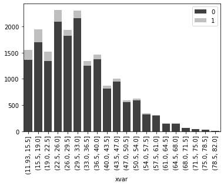

```python
# Draw bar chart by group
M_GphDes(bin, dfana[yvar])
```

```
yvar                  0         1
xvar
(11.93, 15.5]  0.882012  0.117988
(15.5, 19.0]   0.872690  0.127310
(19.0, 22.5]   0.886693  0.113307
(22.5, 26.0]   0.899181  0.100819
(26.0, 29.5]   0.944099  0.055901
(29.5, 33.0]   0.938749  0.061251
(33.0, 36.5]   0.937267  0.062733
(36.5, 40.0]   0.940574  0.059426
(40.0, 43.5]   0.933180  0.066820
(43.5, 47.0]   0.940358  0.059642
(47.0, 50.5]   0.944351  0.055649
(50.5, 54.0]   0.940610  0.059390
(54.0, 57.5]   0.935294  0.064706
(57.5, 61.0]   0.960784  0.039216
(61.0, 64.5]   0.920000  0.080000
(64.5, 68.0]   0.966443  0.033557
(68.0, 71.5]   0.955882  0.044118
(71.5, 75.0]   0.930233  0.069767
(75.0, 78.5]   0.961538  0.038462
(78.5, 82.0]   0.923077  0.076923
```

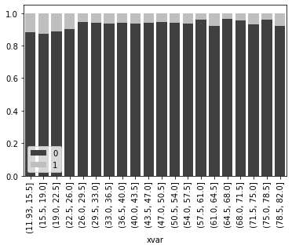

```python
# Draw bar chart by group
M_GphDes(bin, dfana[yvar], '%')
```

```python
from scipy import stats as ss

ss.pearsonr(x = dfana[yvar], y = dfana[vname])
```

```
(-0.08057981391817462, 4.041789395993742e-28)
```

```python
dfana = pd.DataFrame({'xvar' : dfcustinfo.Tariff, 'yvar' : dfchurn.Churn})
dfana.head()
```

|  | xvar | yvar |
| --- | --- | --- |
| 0 | CAT 50 | 1 |
| 1 | CAT 50 | 1 |
| 2 | CAT 50 | 1 |
| 3 | CAT 50 | 0 |
| 4 | CAT 50 | 1 |

```python
vname = "xvar"
yvar = "yvar"
```

```python
#  Output original frequencies/percentages
dfana[vname].value_counts(normalize = True) # normalize / sort
```

```
CAT 200     0.441002
CAT 100     0.218804
Play 100    0.150431
Play 300    0.130119
CAT 50      0.059644
Name: xvar, dtype: float64
```

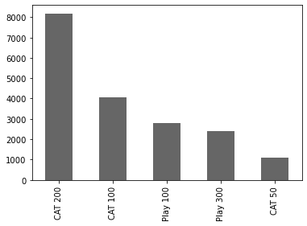

```python
dfana[vname].value_counts().plot.bar(color = '#666666')
```

```
yvar         0    1
xvar
CAT 100   3737  324
CAT 200   7577  608
CAT 50    1018   89
Play 100  2441  351
Play 300  2283  132
```

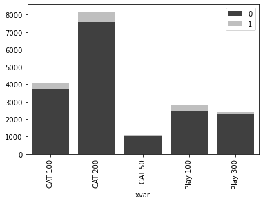

```python
# Bar Chart by Group
M_GphDes(dfana[vname], dfana[yvar])
```

```
yvar             0         1
xvar
CAT 100   0.920217  0.079783
CAT 200   0.925718  0.074282
CAT 50    0.919603  0.080397
Play 100  0.874284  0.125716
Play 300  0.945342  0.054658
```

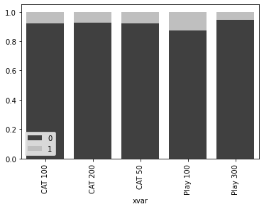

```python
# 100% Bar Chart by Group
M_GphDes(dfana[vname], dfana[yvar], '%')
```

```python
def M_DesC(dfname, xvar, yvar):

    dfname[xvar].value_counts() #  original frequencies/percentages
    dfname[xvar].value_counts().plot.bar(color = '#666666')
    print('Variable Name：', xvar)
    plt.show()
    M_GphDes(dfname[xvar], dfname[yvar]) # bar chart
    M_GphDes(dfname[xvar], dfname[yvar], '%') # 100% bar chart
```

```python
dfana = pd.DataFrame({'Tariff' : dfcustinfo.Tariff, 'Churn' : dfchurn.Churn})
```

```
Variable Name： Tariff
```

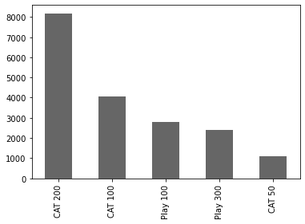

```
Churn        0    1
Tariff
CAT 100   3737  324
CAT 200   7577  608
CAT 50    1018   89
Play 100  2441  351
Play 300  2283  132
```

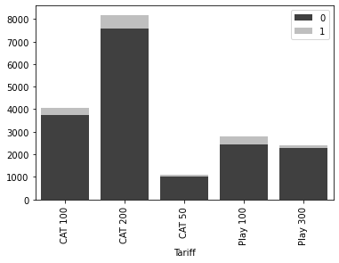

```
Churn            0         1
Tariff
CAT 100   0.920217  0.079783
CAT 200   0.925718  0.074282
CAT 50    0.919603  0.080397
Play 100  0.874284  0.125716
Play 300  0.945342  0.054658
```

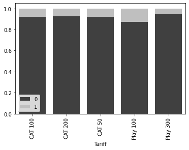

```python
M_DesC(dfana, "Tariff", 'Churn')
```

```python
# Search extreme values and produce simple report
# scanmethod: the definition of extreme values- 5 standard deviation +/ 5 standard errors
# return: dataframe with all variables query results.
def M_ScanVar(dfname, scanmethod = '5sd'):

    dfres = pd.DataFrame(columns = ['Mean', 'SD', 'Min', 'Max', 'Min Extreme', 'Max Extreme'])
    for colname in dfname.columns:
        try:
            if scanmethod == '5sd':
                std = dfname[colname].std()
                mean = dfname[colname].mean()
                dfres.loc[colname] = [std, mean,
                    dfname[colname].min(), dfname[colname].max(),
                    pd.Series(dfname[colname] < mean - 5 * std).sum(),
                    pd.Series(dfname[colname] > mean + 5 * std).sum()
                    ]
        except: # non-numeric variable, return errors
            print(colname + '  Unable to Analyze')
    return dfres
```

```python
M_ScanVar(dfcustcall)
```

```
Customer_ID  Unable to Analyze
```

|  | Mean | SD | Min | Max | Min Extreme | Max Extreme |
| --- | --- | --- | --- | --- | --- | --- |
| Peak_calls | 40.950494 | 39.756397 | 0.000000 | 486.00000 | 0.0 | 236.0 |
| Peak_mins | 91.025244 | 118.768764 | 0.000000 | 2527.80000 | 0.0 | 91.0 |
| OffPeak_calls | 16.684953 | 17.356514 | 0.000000 | 154.00000 | 0.0 | 95.0 |
| OffPeak_mins | 37.630741 | 51.603952 | 0.000000 | 745.50000 | 0.0 | 154.0 |
| Weekend_calls | 3.006471 | 2.790836 | 0.000000 | 33.00000 | 0.0 | 178.0 |
| Weekend_mins | 9.022613 | 8.356949 | 0.000000 | 162.60000 | 0.0 | 557.0 |
| International_mins | 24.371075 | 28.292598 | 0.001518 | 255.50555 | 0.0 | 168.0 |
| Nat_call_cost | 4.709754 | 2.944807 | 0.000000 | 47.00000 | 0.0 | 438.0 |
| month | 1.707833 | 3.500000 | 1.000000 | 6.00000 | 0.0 | 0.0 |

```python
M_ScanVar(dfcustinfo)
```

```
Customer_ID  Unable to Analyze
Gender  Unable to Analyze
Tariff  Unable to Analyze
Handset  Unable to Analyze
```

|  | Mean | SD | Min | Max | Min Extreme | Max Extreme |
| --- | --- | --- | --- | --- | --- | --- |
| Age | 12.847678 | 31.507489 | 12.000000 | 82.0 | 0.0 | 0.0 |
| L_O_S | 14.092156 | 33.708712 | 9.533333 | 58.2 | 0.0 | 0.0 |

### 3.1.2 Data Characteristics Processing

##### Continuous Characteristics Processing

##### Continuous Variables Segmentation

```python
def M_VarBin(dfname, collist = [], binmethod = 'cut',
             binnum = 10, keepvar = True, iscat = True, todumm = False):

    dfnew = copy.copy(dfname)

    if len(collist) == 0:
        collist = dfnew.columns

    catlabel = None
    if not iscat: # Varible become numeric instead of categorical after the change
            catlabel = range(binnum)

    for var in collist:
        if binmethod == 'cut':
            dfnew[var + '_bin'] = pd.cut(dfnew[var], bins = binnum,
                                    labels = catlabel, duplicates = 'drop')
            if todumm:
                dfnew = M_dumm(dfnew, [var + '_bin']) # Change to Dummy Variable Group
            elif not iscat: # Fix a bug in pandas
                dfnew[var + '_bin'] = dfnew[var + '_bin'].astype('int')
        elif binmethod == 'qcut':
            dfnew[var + '_qbin'] = pd.qcut(dfnew[var], q = binnum,
                                    labels = catlabel, duplicates = 'drop')
            if todumm:
                dfnew = M_dumm(dfnew, [var + '_qbin'])
            elif not iscat:
                dfnew[var + '_qbin'] = dfnew[var + '_qbin'].astype('int')

    if not keepvar: # Delete Original Variables
        dfnew.drop(columns = collist, inplace = True)

    return dfnew
```

```python
dfcustinfo.head()
```

|  | Customer_ID | Gender | Age | L_O_S | Tariff | Handset |
| --- | --- | --- | --- | --- | --- | --- |
| 0 | K100130 | M | 45 | 46.566667 | CAT 50 | SOP20 |
| 1 | K100150 | M | 30 | 26.900000 | CAT 50 | SOP20 |
| 2 | K100180 | M | 37 | 27.966667 | CAT 50 | SOP10 |
| 3 | K100270 | M | 44 | 29.833333 | CAT 50 | SOP20 |
| 4 | K100290 | M | 27 | 20.066667 | CAT 50 | SOP20 |

```python
M_VarBin(dfcustinfo, ['Age', 'L_O_S']).head()
```

|  | Customer_ID | Gender | Age | L_O_S | Tariff | Handset | Age_bin | L_O_S_bin |
| --- | --- | --- | --- | --- | --- | --- | --- | --- |
| 0 | K100130 | M | 45 | 46.566667 | CAT 50 | SOP20 | (40.0, 47.0] | (43.6, 48.467] |
| 1 | K100150 | M | 30 | 26.900000 | CAT 50 | SOP20 | (26.0, 33.0] | (24.133, 29.0] |
| 2 | K100180 | M | 37 | 27.966667 | CAT 50 | SOP10 | (33.0, 40.0] | (24.133, 29.0] |
| 3 | K100270 | M | 44 | 29.833333 | CAT 50 | SOP20 | (40.0, 47.0] | (29.0, 33.867] |
| 4 | K100290 | M | 27 | 20.066667 | CAT 50 | SOP20 | (26.0, 33.0] | (19.267, 24.133] |

```python
M_VarBin(dfcustinfo, ['Age', 'L_O_S'], iscat = False).head()
```

|  | Customer_ID | Gender | Age | L_O_S | Tariff | Handset | Age_bin | L_O_S_bin |
| --- | --- | --- | --- | --- | --- | --- | --- | --- |
| 0 | K100130 | M | 45 | 46.566667 | CAT 50 | SOP20 | 4 | 7 |
| 1 | K100150 | M | 30 | 26.900000 | CAT 50 | SOP20 | 2 | 3 |
| 2 | K100180 | M | 37 | 27.966667 | CAT 50 | SOP10 | 3 | 3 |
| 3 | K100270 | M | 44 | 29.833333 | CAT 50 | SOP20 | 4 | 4 |
| 4 | K100290 | M | 27 | 20.066667 | CAT 50 | SOP20 | 2 | 2 |

### 3.1.3 Characteristics Segmentation

##### Dummy Variable Grouping

```python
def M_dumm(dfname, collist = [], namesuffix = '', drop = True):

    dfnew = copy.copy(dfname)
    if len(collist) == 0: # Prepare Variables Name List
        collist = dfname.columns

    binlist = []
    for colname in collist: # Filter Bivariate
        if len(set(dfname[colname])) == 2:
            binlist.append(colname)
            collist.remove(colname)

    prefixlist = []
    for colname in collist: # Prepare Prefix of Dummy Variables
        prefixlist.append(colname + namesuffix)

    binprefixlist = []
    for colname in binlist: # Prepare Prefix of Dummy Bivariate
        binprefixlist.append(colname + namesuffix)

    if len(collist) > 0:
        dfdumm = pd.get_dummies(dfname[collist].astype('str'), prefix = prefixlist)
        dfnew = pd.merge(dfnew, dfdumm, left_index = True, right_index = True)

    if len(binlist) > 0:
        dfdumm = pd.get_dummies(dfname[binlist].astype('str'),
                                drop_first = True, prefix = binprefixlist)
        dfnew = pd.merge(dfnew, dfdumm, left_index = True, right_index = True)

    if drop:
        dfnew.drop(columns = collist, inplace = True)
        dfnew.drop(columns = binlist, inplace = True)

    return dfnew
```

```python
dfcustinfo.head()
```

|  | Customer_ID | Gender | Age | L_O_S | Tariff | Handset |
| --- | --- | --- | --- | --- | --- | --- |
| 0 | K100130 | M | 45 | 46.566667 | CAT 50 | SOP20 |
| 1 | K100150 | M | 30 | 26.900000 | CAT 50 | SOP20 |
| 2 | K100180 | M | 37 | 27.966667 | CAT 50 | SOP10 |
| 3 | K100270 | M | 44 | 29.833333 | CAT 50 | SOP20 |
| 4 | K100290 | M | 27 | 20.066667 | CAT 50 | SOP20 |

```python
M_dumm(dfcustinfo, ['Gender', 'Tariff']).head()
```

|  | Customer_ID | Age | L_O_S | Handset | Tariff_CAT 100 | Tariff_CAT 200 | Tariff_CAT 50 | Tariff_Play 100 | Tariff_Play 300 | Gender_M |
| --- | --- | --- | --- | --- | --- | --- | --- | --- | --- | --- |
| 0 | K100130 | 45 | 46.566667 | SOP20 | 0 | 0 | 1 | 0 | 0 | 1 |
| 1 | K100150 | 30 | 26.900000 | SOP20 | 0 | 0 | 1 | 0 | 0 | 1 |
| 2 | K100180 | 37 | 27.966667 | SOP10 | 0 | 0 | 1 | 0 | 0 | 1 |
| 3 | K100270 | 44 | 29.833333 | SOP20 | 0 | 0 | 1 | 0 | 0 | 1 |
| 4 | K100290 | 27 | 20.066667 | SOP20 | 0 | 0 | 1 | 0 | 0 | 1 |

### 3.1.4 Handling Mission Value

##### Report Missiong Values

```python
print(dfcustcall.shape)
print('Missing Values By Row Report：', dfcustcall.isna().any(1).sum())
print('Missing Values By Colume Report：', dfcustcall.isna().any().sum())
```

```
(111300, 10)
Missing Values By Row Report： 0
Missing Values By Colume Report： 0
```

```python
def M_CheckMissing(dfname):

    cnt = 0
    for col in dfname.columns:
        # MisCount = len(dfname[col]) - len(dfname.loc[dfname[col] == dfname[col]])
        MisCount = dfname[col].isna().sum()
        if MisCount > 0:
            print(col, MisCount)
            cnt += 1
    if cnt == 0:
        print('No missing values in all variables.')
    else:
        print(cnt, 'variables contain missing values.')
```

```python
M_CheckMissing(dfcustcall)
```

```
No missing values in all variables.
```

```python
def M_FillNa(colname, repval = 'mean', naval = []):

    TmpLst = copy.copy(colname) # Protect original data

    if len(naval) > 0: # Replace defined missing values
        TmpLst = TmpLst.replace(naval, np.nan)

    if repval == 'random':
        for i in range(TmpLst.shape[0]): # Go through all values
            if TmpLst.iloc[i] != TmpLst.iloc[i]: # If yes, process missing values
                while True: # Use numeric values to replace
                    rndrepval = TmpLst.iloc[random.randint(0, TmpLst.shape[0] - 1)]
                    if rndrepval == rndrepval: # Make sure extract effective values.
                        break
                TmpLst.iloc[i] = rndrepval
    elif repval == 'mean':
        TmpLst = TmpLst.fillna(TmpLst.mean())
    else:
        TmpLst = TmpLst.fillna(repval)

    return TmpLst
```

```python
tmpdf = copy.copy(dfcustinfo.head(10))
tmpdf.loc[:5, 'Tariff'] = np.NaN
tmpdf
```

|  | Customer_ID | Gender | Age | L_O_S | Tariff | Handset |
| --- | --- | --- | --- | --- | --- | --- |
| 0 | K100130 | M | 45 | 46.566667 | NaN | SOP20 |
| 1 | K100150 | M | 30 | 26.900000 | NaN | SOP20 |
| 2 | K100180 | M | 37 | 27.966667 | NaN | SOP10 |
| 3 | K100270 | M | 44 | 29.833333 | NaN | SOP20 |
| 4 | K100290 | M | 27 | 20.066667 | NaN | SOP20 |
| 5 | K100360 | M | 30 | 45.700000 | NaN | SOP10 |
| 6 | K100430 | M | 35 | 28.433333 | CAT 50 | SOP10 |
| 7 | K100500 | M | 50 | 46.666667 | CAT 50 | SOP20 |
| 8 | K100740 | M | 37 | 11.966667 | CAT 50 | SOP10 |
| 9 | K101010 | M | 28 | 49.300000 | Play 100 | SOP10 |

```python
M_FillNa(tmpdf.Tariff, repval = 'random')
```

```
0      CAT 50
1      CAT 50
2      CAT 50
3      CAT 50
4      CAT 50
5      CAT 50
6      CAT 50
7      CAT 50
8      CAT 50
9    Play 100
Name: Tariff, dtype: object
```

### 3.1.5 Filter Characteristic

##### Remove Constants

```python
# sklearn.feature_selection.VarianceThreshold
tmpdf = copy.copy(dfcustinfo)
tmpdf['cons'] = 1
dfname = tmpdf
for var in dfname.columns:
    if len(set(dfname[var])) == 1:
        dfname.drop(columns = var, inplace = True)
        print(var, "is constant，already deleted")
```

```
cons is constant，already deleted
```

### 3.1.6 Frequently Used Derivative Indicators for Data Preparation

##### Frequently Used Derivative Indicators for Cross-Sectional Data

##### Derivative Indicators based on Time Window

##### Indicators For Trend Analysis and Fluctuation

```python
# Generate intermediate variable for trend and fluctuation analysis
dfcustcall['Peak_mins_month'] = dfcustcall.Peak_mins * dfcustcall.month
dfcustcall['OffPeak_mins_month'] = dfcustcall.OffPeak_mins * dfcustcall.month
dfcustcall['Weekend_mins_month'] = dfcustcall.Weekend_mins * dfcustcall.month
dfcustcall['month_month'] = dfcustcall.month * dfcustcall.month

# Generate all sum-up values grouping by Customer_ID
dfsum = dfcustcall.groupby('Customer_ID').agg('sum')
dfmean = dfcustcall.groupby('Customer_ID').agg('mean')
dfmin = dfcustcall.groupby('Customer_ID').agg('min')
dfmax = dfcustcall.groupby('Customer_ID').agg('max')
dfn = dfcustcall.groupby('Customer_ID').agg('size') # Here, shouldn't use count()

# Calculate the Trend and Fluctuation of Related Variables
dfsum['Peak_mins_Trend'] =  (dfn * dfsum.Peak_mins_month - dfsum.Peak_mins * dfsum.month) / (dfn * dfsum.month_month - dfsum.month * dfsum.month)
dfsum['OffPeak_mins_Trend'] = (dfn * dfsum.OffPeak_mins_month - dfsum.OffPeak_mins * dfsum.month) / (dfn*dfsum.month_month - dfsum.month * dfsum.month)
dfsum['Weekend_mins_Trend'] =  (dfn * dfsum.Weekend_mins_month - dfsum.Weekend_mins * dfsum.month) / (dfn*dfsum.month_month - dfsum.month * dfsum.month)

dfsum['Peak_mins_Fluctuation'] =  (dfmax.Peak_mins - dfmin.Peak_mins) / dfmean.Peak_mins
dfsum['OffPeak_mins_Fluctuation'] =  (dfmax.OffPeak_mins - dfmin.OffPeak_mins) / dfmean.OffPeak_mins
dfsum['Weekend_mins_Fluctuation'] =  (dfmax.Weekend_mins - dfmin.Weekend_mins) / dfmean.Weekend_mins

# Fill in the missing values with random values
dfsum['Peak_mins_Fluctuation'] = M_FillNa(dfsum.Peak_mins_Fluctuation, repval = 'random')
dfsum['OffPeak_mins_Fluctuation'] = M_FillNa(dfsum.OffPeak_mins_Fluctuation, repval = 'random')
dfsum['Weekend_mins_Fluctuation'] = M_FillNa(dfsum.Weekend_mins_Fluctuation, repval = 'random')
```

### 3.1.7 Calculate Aggregate Indicators

#### Aggregate the following indicators for 6 months:

##### 1) Number of Phone Calls during Peak Time, Non-Peak Time, Weekend

##### 2) Duration of Phone Calls during Peak Time, Non-Peak Time, Weekend

##### 3) Duration of Interntional Phone Calls

##### 4) Cost for Domestic Phone Calls

```python
# Aggregate by grouping Customer_ID
# Frequencies and Duration of Domestic Phone Calls
dfsum['National_calls'] = dfsum.Peak_calls + dfsum.OffPeak_calls + dfsum.Weekend_calls
dfsum['National_mins'] = dfsum.Peak_mins + dfsum.OffPeak_mins + dfsum.Weekend_mins

# Ratio during Peak Time, Non-Peak Time, and Weekend
dfsum['Peak_mins_Ratio'] = dfsum.Peak_mins / dfsum.National_mins
dfsum['OffPeak_mins_Ratio'] = dfsum.OffPeak_mins / dfsum.National_mins
dfsum['Weekend_mins_Ratio'] = dfsum.Weekend_mins / dfsum.National_mins

# Total Call Duraiton Ratio
dfsum['All_calls_mins'] = dfsum.National_mins + dfsum.International_mins
# International Call Duration Ratio
dfsum['International_mins_Ratio'] = dfsum.International_mins / dfsum.All_calls_mins

# Average Call Duration during Peak Time, Non-Peak Time, and Weekend
dfsum['AvePeak'] = dfsum.Peak_mins / dfsum.Peak_calls
dfsum['AveOffPeak'] = dfsum.OffPeak_mins / dfsum.OffPeak_calls
dfsum['AveWeekend'] = dfsum.Weekend_mins / dfsum.Weekend_calls
dfsum['AveNational'] = dfsum.National_mins / dfsum.National_calls

# Replace the missing value with zero.
dfsum.fillna({'AvePeak' : 0, 'AveOffPeak' : 0,
              'AveWeekend' : 0, 'AveNational': 0},
             inplace = True)
dfsum.head()
```

| Customer_ID | Peak_calls | Peak_mins | OffPeak_calls | OffPeak_mins | Weekend_calls | Weekend_mins | International_mins | Nat_call_cost | month | Peak_mins_month | ... | National_mins | Peak_mins_Ratio | OffPeak_mins_Ratio | Weekend_mins_Ratio | All_calls_mins | International_mins_Ratio | AvePeak | AveOffPeak | AveWeekend | AveNational |
| --- | --- | --- | --- | --- | --- | --- | --- | --- | --- | --- | --- | --- | --- | --- | --- | --- | --- | --- | --- | --- | --- |
| K100130 | 73 | 63.351716 | 31 | 26.802649 | 1 | 3.045756 | 26.216834 | 0 | 21 | 231.679442 | ... | 93.200121 | 0.679739 | 0.287582 | 0.032680 | 119.416955 | 0.219540 | 0.867832 | 0.864602 | 3.045756 | 0.887620 |
| K100150 | 54 | 96.000000 | 9 | 34.800000 | 14 | 22.800000 | 48.689425 | 0 | 21 | 320.723424 | ... | 153.600000 | 0.625000 | 0.226562 | 0.148437 | 202.289425 | 0.240692 | 1.777778 | 3.866667 | 1.628571 | 1.994805 |
| K100180 | 57 | 41.917551 | 32 | 21.826891 | 6 | 11.988255 | 21.497021 | 0 | 21 | 152.283907 | ... | 75.732697 | 0.553493 | 0.288210 | 0.158297 | 97.229718 | 0.221095 | 0.735396 | 0.682090 | 1.998042 | 0.797186 |
| K100270 | 25 | 41.989655 | 21 | 14.465335 | 1 | 7.433576 | 9.471270 | 0 | 21 | 154.582733 | ... | 63.888566 | 0.657233 | 0.226415 | 0.116352 | 73.359836 | 0.129107 | 1.679586 | 0.688825 | 7.433576 | 1.359331 |
| K100290 | 57 | 90.000000 | 6 | 45.600000 | 20 | 38.499999 | 10.529046 | 0 | 21 | 296.341290 | ... | 174.099999 | 0.516944 | 0.261918 | 0.221137 | 184.629045 | 0.057028 | 1.578947 | 7.600000 | 1.925000 | 2.097590 |

5 rows × 30 columns

```python
# Rename Variables
dfsum.rename(columns = {'Peak_calls' : 'Peak_calls_sum',
                        'Peak_mins' : 'Peak_mins_sum',
                        'OffPeak_calls' : 'OffPeak_calls_sum',
                        'OffPeak_mins' : 'OffPeak_mins_sum',
                        'Weekend_calls' : 'Weekend_calls_sum',
                        'Weekend_mins' : 'Weekend_mins_sum',
                        'International_mins' : 'International_mins_sum',
                        'Nat_call_cost' : 'Nat_call_cost_sum'},
             inplace = True)
# Delete Intermediate Varible
dfsum.drop(columns = ['month', 'Peak_mins_month',
       'OffPeak_mins_month', 'Weekend_mins_month', 'month_month'], inplace = True)
```

```python
# Aggregate All Other Dataset
dfsum = pd.merge(dfsum, dfcustinfo, left_index = True, right_on = 'Customer_ID')
dfsum = pd.merge(dfsum, dftariff, left_on = 'Tariff', right_on = 'Tariff')
```

#### Customer Segmentation by Phone Bill Usage

##### The customers are segmented into the following groups by domestic phone call duration:

##### 1) Low Usage Users: the phone call duration is below the average duration - 1 standard deviation

##### 2) Medium Usage Users: the phone call duration is within the average duration +/- 1 standard deviation

##### 3) High Usage Users: the phone call duration is within the average duration between +/- 1 standard deviation and +/- 2 standard deviation

##### 4) Super Usage Users: the phone call duration is more than the average duration + 2 standard deviation

```python
std = dfsum.National_mins.std()
mean = dfsum.National_mins.mean()
dfsum['National_mins_cls'] = pd.cut(dfsum.National_mins,
                bins = [-np.Inf, mean - std, mean + std, mean + 2 * std, np.Inf],
                labels = ['Low Usage', 'Medium Usage', 'High Usage', 'Super Usage'])
```

```python
dfsum['Mins_charge'] = dfsum.National_mins - dfsum.Free_mins * 6
dfsum['call_cost_per_min'] = (dfsum.Peak_rate * dfsum.Peak_mins_sum +
            dfsum.OffPeak_rate * dfsum.OffPeak_mins_sum +
            dfsum.Weekend_rate * dfsum.Weekend_mins_sum) / dfsum.National_mins
dfsum['actual_call_cost'] = dfsum.Mins_charge * dfsum.call_cost_per_min / 100
dfsum['Total_call_cost'] = dfsum.actual_call_cost + \
            dfsum.International_mins_sum * dfsum.International_rate / 100
dfsum['Total_Cost'] = dfsum.Total_call_cost + dfsum.Fixed_cost * 6
```

```python
#Mark the customers whose current phone plans are not reasonable. The boundary values are provided by the experienced employees.
dfsum['Tariff_OK'] = 'OK'
dfsum.loc[dfsum.query("Tariff == 'CAT 100' and actual_call_cost > 6 * 7.51").index, 'Tariff_OK'] = 'High_CAT_100'
dfsum.loc[dfsum.query("Tariff == 'Play 100' and actual_call_cost > 6 * 3").index, 'Tariff_OK'] = 'High_Play_100'
dfsum.loc[dfsum.query("Tariff == 'CAT 50' and actual_call_cost > 6 * 3.6").index, 'Tariff_OK'] = 'High_CAT_50'

dfsum['average_cost_min'] = dfsum.Total_Cost / dfsum.All_calls_mins

dfsum.drop(columns = ['Fixed_cost', 'Free_mins',
       'Peak_rate', 'OffPeak_rate', 'Weekend_rate', 'International_rate'], inplace = True)
```

```python
'''
dumm1 = pd.get_dummies(dfsum.Tariff_OK, prefix = 'Tariff_c')
dumm2 = pd.get_dummies(dfsum.Gender, prefix = 'Gender_c')
dumm3 = pd.get_dummies(dfsum.National_mins_cls, prefix = 'National_mins_c')

dfsum = pd.merge(dfsum, dumm1, left_index = True, right_index = True)
dfsum = pd.merge(dfsum, dumm2, left_index = True, right_index = True)
dfsum = pd.merge(dfsum, dumm3, left_index = True, right_index = True)

dfsum.drop(columns = ['Tariff_OK', 'Gender', 'National_mins_cls'], inplace = True)

del dumm1, dumm2, dumm3
'''
```

```
"\ndumm1 = pd.get_dummies(dfsum.Tariff_OK, prefix = 'Tariff_c')\ndumm2 = pd.get_dummies(dfsum.Gender, prefix = 'Gender_c')\ndumm3 = pd.get_dummies(dfsum.National_mins_cls, prefix = 'National_mins_c')\n\ndfsum = pd.merge(dfsum, dumm1, left_index = True, right_index = True)\ndfsum = pd.merge(dfsum, du…
```

```python
dfsum = M_dumm(dfsum, ['Handset', 'Tariff', 'Tariff_OK', 'Gender', 'National_mins_cls'])
print(dfsum.shape)
dfsum.head()
```

```
(18550, 59)
```

|  | Peak_calls_sum | Peak_mins_sum | OffPeak_calls_sum | OffPeak_mins_sum | Weekend_calls_sum | Weekend_mins_sum | International_mins_sum | Nat_call_cost_sum | Peak_mins_Trend | OffPeak_mins_Trend | ... | Tariff_Play 300 | Tariff_OK_High_CAT_100 | Tariff_OK_High_CAT_50 | Tariff_OK_High_Play_100 | Tariff_OK_OK | National_mins_cls_High Usage | National_mins_cls_Low Usage | National_mins_cls_Medium Usage | National_mins_cls_Super Usage | Gender_M |
| --- | --- | --- | --- | --- | --- | --- | --- | --- | --- | --- | --- | --- | --- | --- | --- | --- | --- | --- | --- | --- | --- |
| 0 | 73 | 63.351716 | 31 | 26.802649 | 1 | 3.045756 | 26.216834 | 0 | 0.568482 | 0.240512 | ... | 0 | 0 | 0 | 0 | 1 | 0 | 1 | 0 | 0 | 1 |
| 1 | 54 | 96.000000 | 9 | 34.800000 | 14 | 22.800000 | 48.689425 | 0 | -0.872947 | -0.316443 | ... | 0 | 0 | 0 | 0 | 1 | 0 | 1 | 0 | 0 | 1 |
| 2 | 57 | 41.917551 | 32 | 21.826891 | 6 | 11.988255 | 21.497021 | 0 | 0.318427 | 0.165808 | ... | 0 | 0 | 0 | 0 | 1 | 0 | 1 | 0 | 0 | 1 |
| 3 | 25 | 41.989655 | 21 | 14.465335 | 1 | 7.433576 | 9.471270 | 0 | 0.435368 | 0.149983 | ... | 0 | 0 | 0 | 0 | 1 | 0 | 1 | 0 | 0 | 1 |
| 4 | 57 | 90.000000 | 6 | 45.600000 | 20 | 38.499999 | 10.529046 | 0 | -1.066212 | -0.540214 | ... | 0 | 0 | 0 | 0 | 1 | 0 | 1 | 0 | 0 | 1 |

5 rows × 59 columns

```python
# Final Merge and cleaning
dfsum = pd.merge(dfchurn, dfsum, left_on = 'Customer_ID', right_on = 'Customer_ID')
# Delete intermediate variable and dataframe
del dfchurn, dfcustcall, dftariff, dfmax, dfmean, dfmin, mean, std
```

```python
# Set Customer_ID as index
dfsum.set_index('Customer_ID', inplace = True)
```

```python
# Keep original data, and generate random dataset.
dfana = copy.copy(dfsum)
indices = np.arange(dfsum.shape[0])
np.random.shuffle(indices)
dfana = dfana.iloc[indices,:]
```

```python
print(dfana.shape)
dfana.head()
```

```
(18550, 59)
```

| Customer_ID | Churn | Peak_calls_sum | Peak_mins_sum | OffPeak_calls_sum | OffPeak_mins_sum | Weekend_calls_sum | Weekend_mins_sum | International_mins_sum | Nat_call_cost_sum | Peak_mins_Trend | ... | Tariff_Play 300 | Tariff_OK_High_CAT_100 | Tariff_OK_High_CAT_50 | Tariff_OK_High_Play_100 | Tariff_OK_OK | National_mins_cls_High Usage | National_mins_cls_Low Usage | National_mins_cls_Medium Usage | National_mins_cls_Super Usage | Gender_M |
| --- | --- | --- | --- | --- | --- | --- | --- | --- | --- | --- | --- | --- | --- | --- | --- | --- | --- | --- | --- | --- | --- |
| K204540 | 0 | 72 | 170.400000 | 32 | 540.0 | 8 | 23.000000 | 228.845336 | 10 | 1.477972 | ... | 0 | 0 | 0 | 0 | 1 | 0 | 0 | 1 | 0 | 0 |
| K365550 | 0 | 103 | 730.200000 | 90 | 429.6 | 47 | 74.400000 | 90.265020 | 0 | 3.313022 | ... | 0 | 0 | 0 | 0 | 1 | 0 | 0 | 1 | 0 | 0 |
| K117600 | 0 | 494 | 878.399999 | 252 | 424.2 | 0 | 0.000000 | 224.800476 | 7 | 9.241772 | ... | 0 | 0 | 0 | 0 | 1 | 0 | 0 | 1 | 0 | 1 |
| K315940 | 0 | 199 | 1167.000000 | 338 | 794.4 | 16 | 31.800000 | 32.218374 | 59 | 1.295770 | ... | 0 | 0 | 0 | 0 | 1 | 1 | 0 | 0 | 0 | 0 |
| K116710 | 0 | 866 | 1398.600000 | 21 | 89.4 | 16 | 47.499999 | 502.787097 | 29 | -11.306282 | ... | 0 | 0 | 0 | 0 | 1 | 0 | 0 | 1 | 0 | 1 |

5 rows × 59 columns

```python
#keep dataset for simulation later
d_simu = copy.copy(dfana)
indices = np.arange(dfsum.shape[0])
np.random.shuffle(indices)
d_simu = d_simu.iloc[indices,:]
```

```python
collist = ['National_calls', 'National_mins', 'AvePeak','AveOffPeak',
           'AveWeekend', 'AveNational', 'Mins_charge', 'call_cost_per_min',
           'actual_call_cost', 'Total_call_cost', 'Total_Cost',
           'average_cost_min']
dfana = M_VarBin(dfana, collist = collist,
                 keepvar = False, iscat = False, binnum = 100)
print(dfana.shape)
dfana.head()
```

```
(18550, 59)
```

| Customer_ID | Churn | Peak_calls_sum | Peak_mins_sum | OffPeak_calls_sum | OffPeak_mins_sum | Weekend_calls_sum | Weekend_mins_sum | International_mins_sum | Nat_call_cost_sum | Peak_mins_Trend | ... | AvePeak_bin | AveOffPeak_bin | AveWeekend_bin | AveNational_bin | Mins_charge_bin | call_cost_per_min_bin | actual_call_cost_bin | Total_call_cost_bin | Total_Cost_bin | average_cost_min_bin |
| --- | --- | --- | --- | --- | --- | --- | --- | --- | --- | --- | --- | --- | --- | --- | --- | --- | --- | --- | --- | --- | --- |
| K204540 | 0 | 72 | 170.400000 | 32 | 540.0 | 8 | 23.000000 | 228.845336 | 10 | 1.477972 | ... | 0 | 2 | 1 | 10 | 45 | 33 | 69 | 53 | 46 | 25 |
| K365550 | 0 | 103 | 730.200000 | 90 | 429.6 | 47 | 74.400000 | 90.265020 | 0 | 3.313022 | ... | 0 | 0 | 1 | 7 | 43 | 25 | 67 | 43 | 48 | 24 |
| K117600 | 0 | 494 | 878.399999 | 252 | 424.2 | 0 | 0.000000 | 224.800476 | 7 | 9.241772 | ... | 0 | 0 | 0 | 1 | 45 | 27 | 68 | 49 | 53 | 24 |
| K315940 | 0 | 199 | 1167.000000 | 338 | 794.4 | 16 | 31.800000 | 32.218374 | 59 | 1.295770 | ... | 0 | 0 | 1 | 5 | 62 | 25 | 77 | 49 | 53 | 23 |
| K116710 | 0 | 866 | 1398.600000 | 21 | 89.4 | 16 | 47.499999 | 502.787097 | 29 | -11.306282 | ... | 0 | 0 | 1 | 1 | 50 | 32 | 72 | 63 | 66 | 25 |

5 rows × 59 columns

### 3.2.2 Kmeans Cluster Analysis

```python
from sklearn.cluster import KMeans

kmeans = KMeans(n_clusters = 8,
                random_state = 0).fit(dfana[dfana.columns[1:]])
```

```python
Xcls = dfana.groupby(kmeans.labels_)

dfclsdes = Xcls.agg('mean')
dfclsdes.insert(1, 'groupsize', Xcls.Churn.count())
dfclsdes.insert(1, 'grouppct', 100 * dfclsdes.groupsize / len(kmeans.labels_) )

dfclsdes.sort_values('Churn', ascending = False, inplace = True)
dfclsdes.shape
```

```
(8, 61)
```

```python
dfclsdes.T[:15]
```

|  | 3 | 6 | 1 | 5 | 7 | 2 | 4 | 0 |
| --- | --- | --- | --- | --- | --- | --- | --- | --- |
| Churn | 0.128197 | 0.083818 | 0.081814 | 0.078159 | 0.074661 | 0.070727 | 0.063144 | 0.050072 |
| grouppct | 16.862534 | 13.892183 | 13.309973 | 7.380054 | 18.700809 | 2.743935 | 12.037736 | 15.072776 |
| groupsize | 3128.000000 | 2577.000000 | 2469.000000 | 1369.000000 | 3469.000000 | 509.000000 | 2233.000000 | 2796.000000 |
| Peak_calls_sum | 67.164003 | 324.232441 | 384.824220 | 559.612126 | 188.147881 | 758.090373 | 187.780564 | 73.370529 |
| Peak_mins_sum | 208.989861 | 947.922468 | 1182.016525 | 1584.313367 | 558.727818 | 2152.196464 | 611.840125 | 227.177897 |
| OffPeak_calls_sum | 50.711637 | 63.251067 | 117.732280 | 114.654492 | 63.291150 | 127.359528 | 187.512315 | 164.311516 |
| OffPeak_mins_sum | 156.607036 | 199.748894 | 352.908992 | 349.528269 | 191.186480 | 370.875442 | 542.237170 | 474.337124 |
| Weekend_calls_sum | 15.233056 | 16.078386 | 17.200891 | 17.942294 | 16.786970 | 17.094303 | 17.784147 | 17.116595 |
| Weekend_mins_sum | 44.818559 | 49.082227 | 52.666910 | 51.781373 | 50.895330 | 50.842043 | 53.747783 | 50.098176 |
| International_mins_sum | 65.715365 | 158.116454 | 262.466956 | 337.207597 | 116.093967 | 473.163134 | 200.107176 | 120.123385 |
| Nat_call_cost_sum | 2.340473 | 5.629802 | 30.331713 | 67.549306 | 17.644566 | 123.088409 | 3.760860 | 2.255007 |
| Peak_mins_Trend | 1.392523 | 3.873134 | 4.775859 | 7.071990 | 2.734432 | 7.520745 | 2.581521 | 1.458165 |
| OffPeak_mins_Trend | 1.191065 | 1.511553 | 1.824374 | 1.994798 | 1.466857 | 1.817312 | 2.327347 | 2.304149 |
| Weekend_mins_Trend | 0.771491 | 0.795103 | 0.842653 | 0.918974 | 0.907096 | 0.777944 | 0.853356 | 0.789777 |
| Peak_mins_Fluctuation | 0.709779 | 0.487900 | 0.493777 | 0.502030 | 0.530385 | 0.493469 | 0.511307 | 0.670064 |

```python
dfclsdes.T[15:30]
```

|  | 3 | 6 | 1 | 5 | 7 | 2 | 4 | 0 |
| --- | --- | --- | --- | --- | --- | --- | --- | --- |
| OffPeak_mins_Fluctuation | 0.808847 | 0.808725 | 0.641340 | 0.629638 | 0.802615 | 0.664823 | 0.506541 | 0.517259 |
| Weekend_mins_Fluctuation | 1.702537 | 1.604151 | 1.561695 | 1.597690 | 1.671562 | 1.554515 | 1.536687 | 1.589198 |
| Peak_mins_Ratio | 0.506905 | 0.794295 | 0.748128 | 0.800909 | 0.702507 | 0.837687 | 0.505646 | 0.297288 |
| OffPeak_mins_Ratio | 0.374390 | 0.164525 | 0.218551 | 0.172883 | 0.233207 | 0.142396 | 0.449361 | 0.634948 |
| Weekend_mins_Ratio | 0.118704 | 0.041180 | 0.033321 | 0.026207 | 0.064286 | 0.019917 | 0.044993 | 0.067765 |
| All_calls_mins | 476.130820 | 1354.870044 | 1850.059382 | 2322.830607 | 916.903596 | 3047.077083 | 1407.932255 | 871.736582 |
| International_mins_Ratio | 0.137507 | 0.115107 | 0.140022 | 0.143243 | 0.125159 | 0.151973 | 0.140050 | 0.136877 |
| Age | 30.255754 | 31.455568 | 32.236938 | 33.741417 | 31.180167 | 32.506876 | 32.311240 | 30.791845 |
| L_O_S | 33.574158 | 33.584323 | 34.034481 | 33.567495 | 33.927991 | 33.402620 | 33.335946 | 33.845494 |
| Handset_ASAD170 | 0.000639 | 0.135817 | 0.281896 | 0.285610 | 0.069761 | 0.345776 | 0.229288 | 0.072246 |
| Handset_ASAD90 | 0.003197 | 0.037641 | 0.057108 | 0.058437 | 0.019890 | 0.078585 | 0.052396 | 0.031116 |
| Handset_BS110 | 0.309143 | 0.211486 | 0.115026 | 0.090577 | 0.270107 | 0.064833 | 0.096283 | 0.041845 |
| Handset_BS210 | 0.076087 | 0.009701 | 0.000405 | 0.000000 | 0.011819 | 0.000000 | 0.045231 | 0.228541 |
| Handset_CAS30 | 0.038043 | 0.022119 | 0.019036 | 0.010226 | 0.037763 | 0.007859 | 0.016122 | 0.000715 |
| Handset_CAS60 | 0.041240 | 0.000000 | 0.000000 | 0.000000 | 0.002594 | 0.000000 | 0.027318 | 0.100858 |

```python
dfclsdes.T[-30:-15]
```

|  | 3 | 6 | 1 | 5 | 7 | 2 | 4 | 0 |
| --- | --- | --- | --- | --- | --- | --- | --- | --- |
| Handset_S80 | 0.115409 | 0.103609 | 0.151073 | 0.183346 | 0.064572 | 0.194499 | 0.210927 | 0.350143 |
| Handset_SOP10 | 0.009591 | 0.004269 | 0.003645 | 0.005113 | 0.004612 | 0.001965 | 0.002687 | 0.001788 |
| Handset_SOP20 | 0.011189 | 0.003880 | 0.003240 | 0.005113 | 0.006630 | 0.003929 | 0.004030 | 0.003577 |
| Handset_WC95 | 0.180307 | 0.177338 | 0.093560 | 0.073776 | 0.230037 | 0.041257 | 0.100761 | 0.111946 |
| Tariff_CAT 100 | 0.198529 | 0.045402 | 0.000000 | 0.000000 | 0.906025 | 0.000000 | 0.037618 | 0.034335 |
| Tariff_CAT 200 | 0.000000 | 0.954598 | 0.987039 | 1.000000 | 0.068031 | 1.000000 | 0.525302 | 0.000358 |
| Tariff_CAT 50 | 0.353900 | 0.000000 | 0.000000 | 0.000000 | 0.000000 | 0.000000 | 0.000000 | 0.000000 |
| Tariff_Play 100 | 0.443414 | 0.000000 | 0.000000 | 0.000000 | 0.003459 | 0.000000 | 0.000000 | 0.494635 |
| Tariff_Play 300 | 0.004156 | 0.000000 | 0.012961 | 0.000000 | 0.022485 | 0.000000 | 0.437080 | 0.470672 |
| Tariff_OK_High_CAT_100 | 0.000000 | 0.018626 | 0.000000 | 0.000000 | 0.010954 | 0.000000 | 0.000448 | 0.000000 |
| Tariff_OK_High_CAT_50 | 0.008951 | 0.000000 | 0.000000 | 0.000000 | 0.000000 | 0.000000 | 0.000000 | 0.000000 |
| Tariff_OK_High_Play_100 | 0.000000 | 0.000000 | 0.000000 | 0.000000 | 0.000000 | 0.000000 | 0.000000 | 0.006438 |
| Tariff_OK_OK | 0.991049 | 0.981374 | 1.000000 | 1.000000 | 0.989046 | 1.000000 | 0.999552 | 0.993562 |
| National_mins_cls_High Usage | 0.000000 | 0.000000 | 0.428109 | 0.772096 | 0.000000 | 0.031434 | 0.014330 | 0.000000 |
| National_mins_cls_Low Usage | 0.782289 | 0.000000 | 0.000000 | 0.000000 | 0.006630 | 0.000000 | 0.000000 | 0.026824 |

```python
dfclsdes.T[-15:]
```

|  | 3 | 6 | 1 | 5 | 7 | 2 | 4 | 0 |
| --- | --- | --- | --- | --- | --- | --- | --- | --- |
| National_mins_cls_Medium Usage | 0.217711 | 1.000000 | 0.570676 | 0.018992 | 0.993370 | 0.000000 | 0.985670 | 0.973176 |
| National_mins_cls_Super Usage | 0.000000 | 0.000000 | 0.001215 | 0.208912 | 0.000000 | 0.968566 | 0.000000 | 0.000000 |
| Gender_M | 0.463235 | 0.488941 | 0.476306 | 0.503287 | 0.481695 | 0.504912 | 0.480072 | 0.489628 |
| National_calls_bin | 6.053069 | 19.500194 | 25.275415 | 33.834916 | 12.782070 | 44.300589 | 18.971339 | 12.102289 |
| National_mins_bin | 11.025895 | 33.178890 | 44.188335 | 55.403214 | 22.020755 | 71.958743 | 33.483206 | 20.621602 |
| AvePeak_bin | 0.230818 | 0.245634 | 0.381126 | 0.397370 | 0.319400 | 0.518664 | 0.334528 | 0.240701 |
| AveOffPeak_bin | 0.635550 | 0.919286 | 0.845281 | 0.827611 | 0.789565 | 0.732809 | 0.773399 | 0.759299 |
| AveWeekend_bin | 3.048593 | 3.337214 | 3.504253 | 3.705625 | 3.487749 | 3.055010 | 3.510972 | 3.107654 |
| AveNational_bin | 5.298593 | 5.873884 | 6.091130 | 5.734112 | 5.381378 | 6.143418 | 5.206897 | 4.937053 |
| Mins_charge_bin | 40.019501 | 42.754754 | 51.430944 | 61.328707 | 45.413664 | 75.666012 | 36.509628 | 32.090844 |
| call_cost_per_min_bin | 40.589194 | 30.617385 | 29.121102 | 29.952520 | 42.492937 | 30.758350 | 32.385132 | 33.391631 |
| actual_call_cost_bin | 65.053389 | 67.057819 | 71.995545 | 78.099343 | 69.226002 | 87.159136 | 62.162562 | 60.494635 |
| Total_call_cost_bin | 41.376918 | 46.019402 | 53.853382 | 61.331629 | 46.160565 | 73.477407 | 44.967309 | 40.980687 |
| Total_Cost_bin | 37.819054 | 50.242530 | 57.543945 | 64.501096 | 45.668204 | 75.634578 | 45.681594 | 36.615522 |
| average_cost_min_bin | 25.665281 | 24.214203 | 24.010531 | 23.896275 | 24.908907 | 23.829077 | 23.258397 | 22.870529 |

### 3.2.3 Birch Cluster Analysis

```python
from sklearn.cluster import Birch

birch = Birch(n_clusters = 8).fit(dfana[dfana.columns[1:]])
```

```python
pd.crosstab(kmeans.labels_, birch.labels_)
```

| col_0 row_0 | 0 | 1 | 2 | 3 | 4 | 5 | 6 | 7 |
| --- | --- | --- | --- | --- | --- | --- | --- | --- |
| 0 | 6 | 0 | 0 | 1692 | 707 | 391 | 0 | 0 |
| 1 | 101 | 1 | 1648 | 0 | 0 | 0 | 719 | 0 |
| 2 | 0 | 509 | 0 | 0 | 0 | 0 | 0 | 0 |
| 3 | 0 | 0 | 0 | 1141 | 389 | 0 | 0 | 1598 |
| 4 | 1346 | 0 | 57 | 0 | 119 | 711 | 0 | 0 |
| 5 | 0 | 536 | 97 | 0 | 0 | 0 | 736 | 0 |
| 6 | 1871 | 0 | 664 | 0 | 36 | 0 | 6 | 0 |
| 7 | 375 | 0 | 0 | 30 | 3064 | 0 | 0 | 0 |

```python
Xcls = dfana.groupby(birch.labels_)

dfclsdes = Xcls.agg('mean')
dfclsdes.insert(1,'groupsize', Xcls.Churn.count())
dfclsdes.insert(1,'grouppct', 100 * dfclsdes.groupsize / len(kmeans.labels_) )

dfclsdes.sort_values('Churn', ascending = False, inplace = True)
```

```python
dfclsdes.T[:15]
```

|  | 7 | 6 | 0 | 1 | 2 | 4 | 3 | 5 |
| --- | --- | --- | --- | --- | --- | --- | --- | --- |
| Churn | 0.178348 | 0.088296 | 0.078940 | 0.076482 | 0.076237 | 0.070220 | 0.057632 | 0.054446 |
| grouppct | 8.614555 | 7.876011 | 19.940701 | 5.638814 | 13.293801 | 23.261456 | 15.433962 | 5.940701 |
| groupsize | 1598.000000 | 1461.000000 | 3699.000000 | 1046.000000 | 2466.000000 | 4315.000000 | 2863.000000 | 1102.000000 |
| Peak_calls_sum | 56.615144 | 333.347023 | 256.741011 | 725.906310 | 456.319546 | 162.380765 | 60.927698 | 125.245009 |
| Peak_mins_sum | 174.334847 | 1398.777823 | 797.236659 | 1922.461377 | 1140.735766 | 503.696732 | 184.670276 | 382.642650 |
| OffPeak_calls_sum | 29.745932 | 120.777550 | 110.722087 | 124.995220 | 94.309002 | 72.641715 | 129.700314 | 226.984574 |
| OffPeak_mins_sum | 92.716588 | 368.582957 | 326.522709 | 365.941778 | 292.531509 | 220.592399 | 378.664338 | 643.304537 |
| Weekend_calls_sum | 13.810388 | 17.568789 | 17.067315 | 17.655832 | 17.060422 | 16.776362 | 16.605309 | 17.496370 |
| Weekend_mins_sum | 40.394838 | 52.602053 | 51.578129 | 51.217878 | 51.759489 | 50.452005 | 49.020678 | 53.247731 |
| International_mins_sum | 49.999635 | 303.026011 | 178.655899 | 406.208385 | 230.168295 | 114.814642 | 97.054881 | 181.229868 |
| Nat_call_cost_sum | 3.414894 | 51.490760 | 6.120573 | 100.854685 | 22.265207 | 13.766165 | 1.592735 | 0.064428 |
| Peak_mins_Trend | 1.261925 | 6.021734 | 3.559870 | 7.777660 | 4.321778 | 2.518137 | 1.215523 | 1.673669 |
| OffPeak_mins_Trend | 1.012575 | 1.828023 | 1.859668 | 2.138319 | 1.663061 | 1.590295 | 1.826906 | 2.641554 |
| Weekend_mins_Trend | 0.713824 | 0.834649 | 0.870337 | 0.864744 | 0.826365 | 0.854788 | 0.823390 | 0.807292 |
| Peak_mins_Fluctuation | 0.766272 | 0.502667 | 0.505475 | 0.493600 | 0.483380 | 0.538915 | 0.699663 | 0.566905 |

```python
dfclsdes.T[-30:]
```

|  | 7 | 6 | 0 | 1 | 2 | 4 | 3 | 5 |
| --- | --- | --- | --- | --- | --- | --- | --- | --- |
| Handset_S80 | 0.019399 | 0.164271 | 0.127872 | 0.192161 | 0.136253 | 0.101275 | 0.334963 | 0.315789 |
| Handset_SOP10 | 0.013141 | 0.001369 | 0.004055 | 0.005736 | 0.004055 | 0.004171 | 0.003842 | 0.001815 |
| Handset_SOP20 | 0.015019 | 0.006845 | 0.003785 | 0.003824 | 0.002028 | 0.006257 | 0.005239 | 0.004537 |
| Handset_WC95 | 0.174593 | 0.083504 | 0.148959 | 0.059273 | 0.122466 | 0.211124 | 0.142159 | 0.068966 |
| Tariff_CAT 100 | 0.026283 | 0.000000 | 0.097053 | 0.000000 | 0.000000 | 0.777520 | 0.106532 | 0.000000 |
| Tariff_CAT 200 | 0.000000 | 0.992471 | 0.822925 | 1.000000 | 0.995539 | 0.030359 | 0.000000 | 0.053539 |
| Tariff_CAT 50 | 0.630163 | 0.000000 | 0.000000 | 0.000000 | 0.000000 | 0.015295 | 0.011876 | 0.000000 |
| Tariff_Play 100 | 0.342303 | 0.000000 | 0.000000 | 0.000000 | 0.000000 | 0.032677 | 0.730003 | 0.003630 |
| Tariff_Play 300 | 0.001252 | 0.007529 | 0.080022 | 0.000000 | 0.004461 | 0.144148 | 0.151589 | 0.942831 |
| Tariff_OK_High_CAT_100 | 0.000000 | 0.000000 | 0.015680 | 0.000000 | 0.000000 | 0.006721 | 0.000000 | 0.000000 |
| Tariff_OK_High_CAT_50 | 0.004380 | 0.000000 | 0.000000 | 0.000000 | 0.000000 | 0.004635 | 0.000349 | 0.000000 |
| Tariff_OK_High_Play_100 | 0.000000 | 0.000000 | 0.000000 | 0.000000 | 0.000000 | 0.002549 | 0.002445 | 0.000000 |
| Tariff_OK_OK | 0.995620 | 1.000000 | 0.984320 | 1.000000 | 1.000000 | 0.986095 | 0.997206 | 1.000000 |
| National_mins_cls_High Usage | 0.000000 | 0.819302 | 0.013247 | 0.325048 | 0.233577 | 0.000000 | 0.000000 | 0.000000 |
| National_mins_cls_Low Usage | 0.989987 | 0.000000 | 0.000000 | 0.000000 | 0.000000 | 0.045423 | 0.267901 | 0.000000 |
| National_mins_cls_Medium Usage | 0.010013 | 0.128679 | 0.986753 | 0.000000 | 0.766423 | 0.954577 | 0.732099 | 1.000000 |
| National_mins_cls_Super Usage | 0.000000 | 0.052019 | 0.000000 | 0.674952 | 0.000000 | 0.000000 | 0.000000 | 0.000000 |
| Gender_M | 0.428661 | 0.467488 | 0.489592 | 0.509560 | 0.487024 | 0.480881 | 0.500524 | 0.473684 |
| National_calls_bin | 4.417397 | 22.885695 | 18.555556 | 42.601338 | 27.653285 | 11.957822 | 9.740133 | 17.814882 |
| National_mins_bin | 8.120150 | 50.748118 | 32.567721 | 65.356597 | 41.295215 | 21.286443 | 16.706951 | 29.868421 |
| AvePeak_bin | 0.204631 | 0.718001 | 0.381995 | 0.308795 | 0.128954 | 0.321900 | 0.208523 | 0.196007 |
| AveOffPeak_bin | 0.616395 | 0.872690 | 0.851041 | 0.745698 | 0.868613 | 0.782387 | 0.666434 | 0.839383 |
| AveWeekend_bin | 2.870463 | 3.516769 | 3.518519 | 3.416826 | 3.433496 | 3.345075 | 3.207475 | 3.308530 |
| AveNational_bin | 5.419274 | 8.634497 | 5.791025 | 5.182600 | 4.386050 | 5.432445 | 4.860286 | 5.024501 |
| Mins_charge_bin | 39.619524 | 57.188227 | 41.818059 | 69.952199 | 49.054745 | 41.879490 | 38.121551 | 25.470054 |
| call_cost_per_min_bin | 41.372340 | 29.481862 | 30.677751 | 30.415870 | 29.450122 | 43.039629 | 34.519735 | 32.544465 |
| actual_call_cost_bin | 64.635169 | 75.467488 | 66.287645 | 83.543021 | 70.647607 | 66.406257 | 64.519036 | 56.101633 |
| Total_call_cost_bin | 40.244681 | 58.054073 | 46.467153 | 68.139579 | 51.527981 | 44.189571 | 42.852951 | 40.610708 |
| Total_Cost_bin | 36.637672 | 61.433949 | 49.719654 | 70.744742 | 55.486212 | 43.093627 | 38.069508 | 37.632486 |
| average_cost_min_bin | 26.521902 | 23.928816 | 24.126791 | 23.827916 | 24.050689 | 24.454229 | 23.884387 | 22.119782 |

### 3.2.4 Generate Rules Sets by Decision Tree Model

##### Data Split

```python
dfana.head()
```

| Customer_ID | Churn | Peak_calls_sum | Peak_mins_sum | OffPeak_calls_sum | OffPeak_mins_sum | Weekend_calls_sum | Weekend_mins_sum | International_mins_sum | Nat_call_cost_sum | Peak_mins_Trend | ... | AvePeak_bin | AveOffPeak_bin | AveWeekend_bin | AveNational_bin | Mins_charge_bin | call_cost_per_min_bin | actual_call_cost_bin | Total_call_cost_bin | Total_Cost_bin | average_cost_min_bin |
| --- | --- | --- | --- | --- | --- | --- | --- | --- | --- | --- | --- | --- | --- | --- | --- | --- | --- | --- | --- | --- | --- |
| K204540 | 0 | 72 | 170.400000 | 32 | 540.0 | 8 | 23.000000 | 228.845336 | 10 | 1.477972 | ... | 0 | 2 | 1 | 10 | 45 | 33 | 69 | 53 | 46 | 25 |
| K365550 | 0 | 103 | 730.200000 | 90 | 429.6 | 47 | 74.400000 | 90.265020 | 0 | 3.313022 | ... | 0 | 0 | 1 | 7 | 43 | 25 | 67 | 43 | 48 | 24 |
| K117600 | 0 | 494 | 878.399999 | 252 | 424.2 | 0 | 0.000000 | 224.800476 | 7 | 9.241772 | ... | 0 | 0 | 0 | 1 | 45 | 27 | 68 | 49 | 53 | 24 |
| K315940 | 0 | 199 | 1167.000000 | 338 | 794.4 | 16 | 31.800000 | 32.218374 | 59 | 1.295770 | ... | 0 | 0 | 1 | 5 | 62 | 25 | 77 | 49 | 53 | 23 |
| K116710 | 0 | 866 | 1398.600000 | 21 | 89.4 | 16 | 47.499999 | 502.787097 | 29 | -11.306282 | ... | 0 | 0 | 1 | 1 | 50 | 32 | 72 | 63 | 66 | 25 |

5 rows × 59 columns

```python
from sklearn.model_selection import train_test_split

X_train, X_test, y_train, y_test = train_test_split(dfana[dfana.columns[1:]],
                dfana.Churn, test_size = 0.3, random_state = 123)
```

##### Rules Exploration by Using Tree Model

```python
from sklearn.tree import DecisionTreeClassifier

# Use default setting for preliminary exploration.
ct = DecisionTreeClassifier()
ct.fit(X_train, y_train)
```

```
DecisionTreeClassifier()
```

```python
from sklearn.metrics import classification_report

print(classification_report(y_train, ct.predict(X_train)))

print(classification_report(y_test, ct.predict(X_test)))
```

```
              precision    recall  f1-score   support

           0       1.00      1.00      1.00     11959
           1       1.00      1.00      1.00      1026

    accuracy                           1.00     12985
   macro avg       1.00      1.00      1.00     12985
weighted avg       1.00      1.00      1.00     12985

              precision    recall  f1-score   support

           0       0.96      0.96      0.96      5089
           1       0.57      0.53      0.55       476

    accuracy                           0.93      5565
   macro avg       0.76      0.75      0.75      5565
weighted avg       0.92      0.93      0.92      5565
```

```python
# Reduce the classification layers and obseve the effect.
ct = DecisionTreeClassifier(max_depth = 5)
ct.fit(X_train, y_train)
```

```
DecisionTreeClassifier(max_depth=5)
```

```python
print(classification_report(y_train, ct.predict(X_train)))

print(classification_report(y_test, ct.predict(X_test)))
```

```
              precision    recall  f1-score   support

           0       0.96      0.98      0.97     11959
           1       0.68      0.58      0.63      1026

    accuracy                           0.95     12985
   macro avg       0.82      0.78      0.80     12985
weighted avg       0.94      0.95      0.94     12985

              precision    recall  f1-score   support

           0       0.96      0.97      0.97      5089
           1       0.66      0.53      0.59       476

    accuracy                           0.94      5565
   macro avg       0.81      0.75      0.78      5565
weighted avg       0.93      0.94      0.93      5565
```

```python
# Observe both text and graph outputs.
from sklearn.tree import export_graphviz

export_graphviz(ct, out_file = 'tree.dot', feature_names = dfana.columns[1:],
                node_ids = True, proportion = True)
```

##### Directly use tree model to predict

##### Use cross validation for a more stable result

```python
from sklearn.model_selection import cross_val_score

ct = DecisionTreeClassifier()
```

```python
scores = cross_val_score(ct, dfana[dfana.columns[1:]], dfana.Churn, cv = 5)
scores
```

```
array([0.92803235, 0.92641509, 0.93342318, 0.92803235, 0.92345013])
```

```python
from sklearn.model_selection import cross_val_predict

pred = cross_val_predict(ct, dfana[dfana.columns[1:]],
                         dfana.Churn, cv = 5, method = 'predict_proba')
```

```python
pd.DataFrame(pred).head()
```

|  | 0 | 1 |
| --- | --- | --- |
| 0 | 1.0 | 0.0 |
| 1 | 1.0 | 0.0 |
| 2 | 1.0 | 0.0 |
| 3 | 1.0 | 0.0 |
| 4 | 0.0 | 1.0 |

##### Use Random Forest Model to Predict

```python
from sklearn.ensemble import RandomForestClassifier

rfc = RandomForestClassifier(500)
rfc.fit(X_train, y_train)
```

```
RandomForestClassifier(n_estimators=500)
```

```python
from sklearn.metrics import classification_report

print(classification_report(y_test, rfc.predict(X_test)))
```

```
              precision    recall  f1-score   support

           0       0.96      0.98      0.97      5089
           1       0.68      0.55      0.61       476

    accuracy                           0.94      5565
   macro avg       0.82      0.76      0.79      5565
weighted avg       0.93      0.94      0.94      5565
```

### 3.2.5 Calculate Churn Scores Using Neural Network

##### Neural Network Model Fitting

```python
dfana.head()
```

| Customer_ID | Churn | Peak_calls_sum | Peak_mins_sum | OffPeak_calls_sum | OffPeak_mins_sum | Weekend_calls_sum | Weekend_mins_sum | International_mins_sum | Nat_call_cost_sum | Peak_mins_Trend | ... | AvePeak_bin | AveOffPeak_bin | AveWeekend_bin | AveNational_bin | Mins_charge_bin | call_cost_per_min_bin | actual_call_cost_bin | Total_call_cost_bin | Total_Cost_bin | average_cost_min_bin |
| --- | --- | --- | --- | --- | --- | --- | --- | --- | --- | --- | --- | --- | --- | --- | --- | --- | --- | --- | --- | --- | --- |
| K204540 | 0 | 72 | 170.400000 | 32 | 540.0 | 8 | 23.000000 | 228.845336 | 10 | 1.477972 | ... | 0 | 2 | 1 | 10 | 45 | 33 | 69 | 53 | 46 | 25 |
| K365550 | 0 | 103 | 730.200000 | 90 | 429.6 | 47 | 74.400000 | 90.265020 | 0 | 3.313022 | ... | 0 | 0 | 1 | 7 | 43 | 25 | 67 | 43 | 48 | 24 |
| K117600 | 0 | 494 | 878.399999 | 252 | 424.2 | 0 | 0.000000 | 224.800476 | 7 | 9.241772 | ... | 0 | 0 | 0 | 1 | 45 | 27 | 68 | 49 | 53 | 24 |
| K315940 | 0 | 199 | 1167.000000 | 338 | 794.4 | 16 | 31.800000 | 32.218374 | 59 | 1.295770 | ... | 0 | 0 | 1 | 5 | 62 | 25 | 77 | 49 | 53 | 23 |
| K116710 | 0 | 866 | 1398.600000 | 21 | 89.4 | 16 | 47.499999 | 502.787097 | 29 | -11.306282 | ... | 0 | 0 | 1 | 1 | 50 | 32 | 72 | 63 | 66 | 25 |

5 rows × 59 columns

```python
# standardize independent variables
from sklearn.preprocessing import scale

dfanaz = scale(dfana[dfana.columns[1:]])
```

```python
from sklearn.model_selection import train_test_split

X_train, X_test, y_train, y_test = train_test_split(dfanaz, dfana.Churn,
                 test_size = 0.3, random_state = 123)
```

```python
from sklearn.neural_network import MLPClassifier
clf = MLPClassifier(random_state = 123)
```

```python
clf.fit(X_train, y_train)
```

```
MLPClassifier(random_state=123)
```

```python
print(clf.score(X_train, y_train), clf.score(X_test, y_test))
```

```
0.9856757797458606 0.9344115004492363
```

```python
from sklearn.metrics import classification_report

print(classification_report(y_train, clf.predict(X_train)))
print(classification_report(y_test, clf.predict(X_test)))
```

```
              precision    recall  f1-score   support

           0       0.99      0.99      0.99     11959
           1       0.92      0.90      0.91      1026

    accuracy                           0.99     12985
   macro avg       0.95      0.95      0.95     12985
weighted avg       0.99      0.99      0.99     12985

              precision    recall  f1-score   support

           0       0.96      0.97      0.96      5089
           1       0.64      0.55      0.59       476

    accuracy                           0.93      5565
   macro avg       0.80      0.76      0.78      5565
weighted avg       0.93      0.93      0.93      5565
```

###### Above shows the model is overfitting，therefore consider to use early_stopping with the cost of sacrifice of 10% training set

```python
from sklearn.neural_network import MLPClassifier

clf = MLPClassifier(random_state = 123, early_stopping = True)
clf.fit(X_train, y_train)
```

```
MLPClassifier(early_stopping=True, random_state=123)
```

```python
print(clf.score(X_train, y_train), clf.score(X_test, y_test))
```

```
0.9445514054678475 0.9394429469901168
```

```python
from sklearn.metrics import classification_report

print(classification_report(y_test, clf.predict(X_test)))
```

```
              precision    recall  f1-score   support

           0       0.96      0.98      0.97      5089
           1       0.68      0.55      0.61       476

    accuracy                           0.94      5565
   macro avg       0.82      0.76      0.79      5565
weighted avg       0.93      0.94      0.94      5565
```

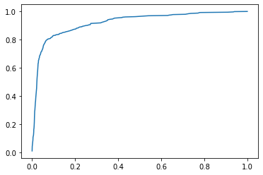

```python
from sklearn.metrics import roc_curve

fpr, tpr, thresholds = roc_curve(y_test, clf.predict_proba(X_test)[:, 1])
sns.lineplot(fpr, tpr, ci = None)
```

```python
from sklearn.metrics import roc_auc_score

print(roc_auc_score(y_train, clf.predict_proba(X_train)[:, 1]),
      roc_auc_score(y_test, clf.predict_proba(X_test)[:, 1]))
```

```
0.9395719650977749 0.9213834089344128
```

##### Cross Validation

```python
from sklearn.model_selection import cross_val_score

scores = cross_val_score(clf, dfanaz, dfana.Churn,
                         scoring = 'roc_auc', cv = 3)
print(scores.mean())
scores
```

```
0.9290331951305569
```

```
array([0.92813704, 0.93095689, 0.92800566])
```

#### Parameter Tuning for Neural Network Modelling

```python
from sklearn.model_selection import GridSearchCV

parameters = {'activation' : ['relu', 'logistic', 'tanh']}

# early_stopping will interfere with the filter results, here stop using it.
clf = MLPClassifier(max_iter = 500, random_state = 123)

clf2 = GridSearchCV(clf, parameters, cv = 3, n_jobs = -1, verbose = 1,
                    scoring = 'roc_auc', return_train_score = True)
clf2.fit(dfanaz, dfana.Churn)
```

```
Fitting 3 folds for each of 3 candidates, totalling 9 fits
```

```
[Parallel(n_jobs=-1)]: Using backend LokyBackend with 8 concurrent workers.
[Parallel(n_jobs=-1)]: Done   4 out of   9 | elapsed:   59.2s remaining:  1.2min
[Parallel(n_jobs=-1)]: Done   9 out of   9 | elapsed:  1.2min finished
```

```
GridSearchCV(cv=3, estimator=MLPClassifier(max_iter=500, random_state=123),
             n_jobs=-1, param_grid={'activation': ['relu', 'logistic', 'tanh']},
             return_train_score=True, scoring='roc_auc', verbose=1)
```

```python
pd.DataFrame(clf2.cv_results_)
```

|  | mean_fit_time | std_fit_time | mean_score_time | std_score_time | param_activation | params | split0_test_score | split1_test_score | split2_test_score | mean_test_score | std_test_score | rank_test_score | split0_train_score | split1_train_score | split2_train_score | mean_train_score | std_train_score |
| --- | --- | --- | --- | --- | --- | --- | --- | --- | --- | --- | --- | --- | --- | --- | --- | --- | --- |
| 0 | 63.628642 | 2.446844 | 0.024023 | 0.001737 | relu | {'activation': 'relu'} | 0.889645 | 0.890404 | 0.907067 | 0.895705 | 0.008040 | 3 | 0.999510 | 0.999979 | 0.999952 | 0.999814 | 2.147139e-04 |
| 1 | 56.893235 | 0.180086 | 0.025266 | 0.002618 | logistic | {'activation': 'logistic'} | 0.912610 | 0.903604 | 0.909941 | 0.908718 | 0.003777 | 1 | 0.999998 | 0.999999 | 0.999999 | 0.999999 | 2.310964e-07 |
| 2 | 39.239028 | 8.073906 | 0.040890 | 0.019150 | tanh | {'activation': 'tanh'} | 0.902006 | 0.899638 | 0.901626 | 0.901090 | 0.001039 | 2 | 1.000000 | 1.000000 | 1.000000 | 1.000000 | 1.243115e-07 |

```python
pd.DataFrame(clf2.cv_results_).sort_values('rank_test_score').iloc[:5,:].T
```

|  | 1 | 2 | 0 |
| --- | --- | --- | --- |
| mean_fit_time | 56.8932 | 39.239 | 63.6286 |
| std_fit_time | 0.180086 | 8.07391 | 2.44684 |
| mean_score_time | 0.0252662 | 0.0408898 | 0.0240231 |
| std_score_time | 0.00261764 | 0.0191499 | 0.00173676 |
| param_activation | logistic | tanh | relu |
| params | {'activation': 'logistic'} | {'activation': 'tanh'} | {'activation': 'relu'} |
| split0_test_score | 0.91261 | 0.902006 | 0.889645 |
| split1_test_score | 0.903604 | 0.899638 | 0.890404 |
| split2_test_score | 0.909941 | 0.901626 | 0.907067 |
| mean_test_score | 0.908718 | 0.90109 | 0.895705 |
| std_test_score | 0.00377706 | 0.00103872 | 0.00803968 |
| rank_test_score | 1 | 2 | 3 |
| split0_train_score | 0.999998 | 1 | 0.99951 |
| split1_train_score | 0.999999 | 1 | 0.999979 |
| split2_train_score | 0.999999 | 1 | 0.999952 |
| mean_train_score | 0.999999 | 1 | 0.999814 |
| std_train_score | 2.31096e-07 | 1.24312e-07 | 0.000214714 |

```python
clf2.best_estimator_
```

```
MLPClassifier(activation='logistic', max_iter=500, random_state=123)
```

#### Optimize alpha based on filtering clf2 (penalty parameters).

```python
import numpy as np
from sklearn.model_selection import validation_curve

train_scores, test_scores = validation_curve(clf2.best_estimator_,
            dfanaz, dfana.Churn, "alpha", np.logspace(-4, 1, 6), cv = 3)
```

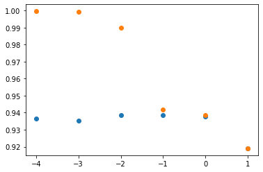

```python
plt.scatter(np.linspace(-4, 1, 6), np.mean(test_scores, axis = 1))
plt.scatter(np.linspace(-4, 1, 6), np.mean(train_scores, axis = 1))
```

#### Tuning other parameters

```python
from sklearn.model_selection import GridSearchCV

parameters = {'hidden_layer_sizes' : [(50,), (70,), (100,), (120,), (150,)]}

clf = MLPClassifier(activation = 'logistic', alpha = 0.1,
                    max_iter = 500, random_state = 123)

clf2 = GridSearchCV(clf, parameters, cv = 3, n_jobs = -1, verbose = 1,
                    scoring = 'roc_auc', return_train_score = True)
clf2.fit(dfanaz, dfana.Churn)
```

```
Fitting 3 folds for each of 5 candidates, totalling 15 fits
```

```
[Parallel(n_jobs=-1)]: Using backend LokyBackend with 8 concurrent workers.
[Parallel(n_jobs=-1)]: Done  15 out of  15 | elapsed:   39.5s finished
```

```
GridSearchCV(cv=3,
             estimator=MLPClassifier(activation='logistic', alpha=0.1,
                                     max_iter=500, random_state=123),
             n_jobs=-1,
             param_grid={'hidden_layer_sizes': [(50,), (70,), (100,), (120,),
                                                (150,)]},
             return_train_score=True, scoring='roc_auc', verbose=1)
```

```python
pd.DataFrame(clf2.cv_results_).sort_values('rank_test_score').iloc[:5,:].T
```

|  | 0 | 1 | 4 | 3 | 2 |
| --- | --- | --- | --- | --- | --- |
| mean_fit_time | 15.7481 | 15.9298 | 14.8129 | 15.5717 | 16.6242 |
| std_fit_time | 3.76617 | 5.45936 | 0.935633 | 0.491368 | 2.80985 |
| mean_score_time | 0.0206109 | 0.0259306 | 0.022938 | 0.0274301 | 0.0355716 |
| std_score_time | 0.00046991 | 0.000815075 | 0.00570027 | 0.00147342 | 0.0044843 |
| param_hidden_layer_sizes | (50,) | (70,) | (150,) | (120,) | (100,) |
| params | {'hidden_layer_sizes': (50,)} | {'hidden_layer_sizes': (70,)} | {'hidden_layer_sizes': (150,)} | {'hidden_layer_sizes': (120,)} | {'hidden_layer_sizes': (100,)} |
| split0_test_score | 0.92967 | 0.928707 | 0.926503 | 0.926539 | 0.926265 |
| split1_test_score | 0.926922 | 0.925215 | 0.925978 | 0.926002 | 0.9254 |
| split2_test_score | 0.92746 | 0.92674 | 0.927006 | 0.926745 | 0.926333 |
| mean_test_score | 0.928017 | 0.926887 | 0.926496 | 0.926429 | 0.926 |
| std_test_score | 0.00118943 | 0.00142933 | 0.000419596 | 0.000313311 | 0.000424676 |
| rank_test_score | 1 | 2 | 3 | 4 | 5 |
| split0_train_score | 0.941811 | 0.939764 | 0.93356 | 0.933773 | 0.93606 |
| split1_train_score | 0.936407 | 0.933762 | 0.935506 | 0.934023 | 0.935233 |
| split2_train_score | 0.935752 | 0.934096 | 0.934901 | 0.932634 | 0.933134 |
| mean_train_score | 0.93799 | 0.935874 | 0.934656 | 0.933477 | 0.934809 |
| std_train_score | 0.00271477 | 0.00275415 | 0.0008131 | 0.000604478 | 0.0012314 |

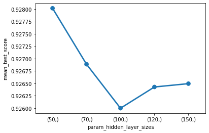

```python
res = pd.DataFrame(clf2.cv_results_)

sns.pointplot(x = res.param_hidden_layer_sizes, y = res.mean_test_score)
```

```python
from sklearn.model_selection import GridSearchCV

parameters = {'alpha': np.linspace(0.05, 0.5, 10)}

clf3 = GridSearchCV(clf2.best_estimator_, parameters,
                    cv = 3, n_jobs = -1, verbose = 1,
                    scoring = 'roc_auc', return_train_score = True)
clf3.fit(dfanaz, dfana.Churn)
```

```
Fitting 3 folds for each of 10 candidates, totalling 30 fits
```

```
[Parallel(n_jobs=-1)]: Using backend LokyBackend with 8 concurrent workers.
[Parallel(n_jobs=-1)]: Done  30 out of  30 | elapsed:   51.5s finished
```

```
GridSearchCV(cv=3,
             estimator=MLPClassifier(activation='logistic', alpha=0.1,
                                     hidden_layer_sizes=(50,), max_iter=500,
                                     random_state=123),
             n_jobs=-1,
             param_grid={'alpha': array([0.05, 0.1 , 0.15, 0.2 , 0.25, 0.3 , 0.35, 0.4 , 0.45, 0.5 ])},
             return_train_score=True, scoring='roc_auc', verbose=1)
```

```python
pd.DataFrame(clf3.cv_results_).sort_values('rank_test_score').iloc[:5,:].T
```

|  | 0 | 1 | 2 | 3 | 4 |
| --- | --- | --- | --- | --- | --- |
| mean_fit_time | 39.0556 | 17.2911 | 13.042 | 11.8169 | 9.70869 |
| std_fit_time | 8.10874 | 3.94211 | 1.00054 | 1.75502 | 0.966124 |
| mean_score_time | 0.0196142 | 0.0227768 | 0.026595 | 0.0265958 | 0.0229387 |
| std_score_time | 0.00329099 | 0.00143514 | 0.00463036 | 0.00463024 | 0.000814199 |
| param_alpha | 0.05 | 0.1 | 0.15 | 0.2 | 0.25 |
| params | {'alpha': 0.05} | {'alpha': 0.1} | {'alpha': 0.15000000000000002} | {'alpha': 0.2} | {'alpha': 0.25} |
| split0_test_score | 0.93423 | 0.92967 | 0.927132 | 0.926499 | 0.924615 |
| split1_test_score | 0.936049 | 0.926922 | 0.925408 | 0.924173 | 0.923657 |
| split2_test_score | 0.932993 | 0.92746 | 0.925793 | 0.924212 | 0.923502 |
| mean_test_score | 0.934424 | 0.928017 | 0.926111 | 0.924962 | 0.923925 |
| std_test_score | 0.00125483 | 0.00118943 | 0.000738786 | 0.0010874 | 0.000492409 |
| rank_test_score | 1 | 2 | 3 | 4 | 5 |
| split0_train_score | 0.955353 | 0.941811 | 0.933543 | 0.93201 | 0.929873 |
| split1_train_score | 0.966737 | 0.936407 | 0.933559 | 0.931938 | 0.930829 |
| split2_train_score | 0.962537 | 0.935752 | 0.932306 | 0.930124 | 0.929217 |
| mean_train_score | 0.961542 | 0.93799 | 0.933136 | 0.931357 | 0.929973 |
| std_train_score | 0.00470075 | 0.00271477 | 0.000586737 | 0.000872771 | 0.000662023 |

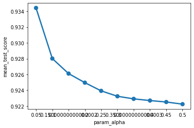

```python
res = pd.DataFrame(clf3.cv_results_)

sns.pointplot(x = res.param_alpha, y = res.mean_test_score)
```

```python
from sklearn.model_selection import GridSearchCV

parameters = {'alpha': np.linspace(0., 0.1, 11)}

clf3 = GridSearchCV(clf2.best_estimator_, parameters,
                    cv = 3, n_jobs = -1, verbose = 1,
                    scoring = 'roc_auc', return_train_score = True)
clf3.fit(dfanaz, dfana.Churn)
```

```
Fitting 3 folds for each of 11 candidates, totalling 33 fits
```

```
[Parallel(n_jobs=-1)]: Using backend LokyBackend with 8 concurrent workers.
[Parallel(n_jobs=-1)]: Done  33 out of  33 | elapsed:  3.6min finished
```

```
GridSearchCV(cv=3,
             estimator=MLPClassifier(activation='logistic', alpha=0.1,
                                     hidden_layer_sizes=(50,), max_iter=500,
                                     random_state=123),
             n_jobs=-1,
             param_grid={'alpha': array([0.  , 0.01, 0.02, 0.03, 0.04, 0.05, 0.06, 0.07, 0.08, 0.09, 0.1 ])},
             return_train_score=True, scoring='roc_auc', verbose=1)
```

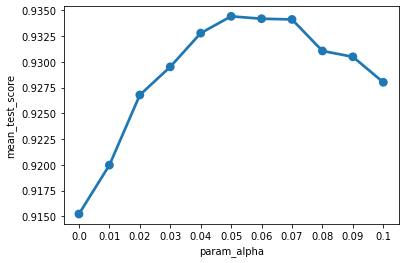

```python
res = pd.DataFrame(clf3.cv_results_)

sns.pointplot(x = res.param_alpha, y = res.mean_test_score)
```

```python
clf3.best_estimator_
```

```
MLPClassifier(activation='logistic', alpha=0.05, hidden_layer_sizes=(50,),
              max_iter=500, random_state=123)
```

```python
pred0 = pd.DataFrame(clf3.best_estimator_.predict_proba(dfanaz))[1]
pred0.head()
```

```
0    0.007685
1    0.021909
2    0.042554
3    0.001204
4    0.799526
Name: 1, dtype: float64
```

## 3.3 Model Application and Sales Simulation

### 3.3.1 Sales Simulation

##### Set Basic Dataframe for Sales Simulation

```python
dfsimu = d_simu[['Churn', 'Total_Cost']]
dfsimu.columns = ['Churn', 'Customer_Values']
simusize = len(d_simu)
dfsimu.reset_index(drop = False, inplace = True)
```

```python
dfsimu.head()
```

|  | Customer_ID | Churn | Customer_Values |
| --- | --- | --- | --- |
| 0 | K386280 | 0 | 103.236784 |
| 1 | K262860 | 0 | 116.266057 |
| 2 | K291090 | 0 | 166.469144 |
| 3 | K143500 | 0 | 304.694989 |
| 4 | K266090 | 0 | 100.025175 |

```python
# Calculate Churn Scores
pred0 = pd.DataFrame(clf3.best_estimator_.predict_proba(dfanaz))[1]
dfsimu.loc[:, 'Churn_Scores'] = 100 * (pred0 - pred0.min()) / (pred0.max() - pred0.min())
dfsimu.sort_values(['Churn_Scores'], ascending = False, inplace = True)
dfsimu.reset_index(drop = True, inplace = True)
dfsimu.head()
```

|  | Customer_ID | Churn | Customer_Values | Churn_Scores |
| --- | --- | --- | --- | --- |
| 0 | K299110 | 0 | 165.306390 | 100.000000 |
| 1 | K381620 | 0 | 82.458145 | 99.649181 |
| 2 | K153050 | 0 | 283.737214 | 99.232994 |
| 3 | K285080 | 0 | 175.035633 | 98.433994 |
| 4 | K401570 | 0 | 210.875834 | 98.146262 |

```python
# Calculate accumulated customers ratio based on transacton sequences.
dfsimu.loc[:, 'Target_Customer_Ratio'] = 100 * (dfsimu.index + 1) / simusize
```

#### Set Sales Parameters

```python
Response_Ratio = 50
Discount_Ratio = 30 # Sales promotion discount rate(percentage)
Sales_Pro_Cost_Unit= 10
```

```python
#  Sales Response Simulation on Random Numbers
'''
dfsimu['Sales_Response'] = 0
for i in range(simusize):
    if np.random.random() < Response_Ratio / 100:
        dfsimu.loc[i, ['Sales_Response']] = 1
'''
```

```
"\ndfsimu['Sales_Response'] = 0\nfor i in range(simusize):\n    if np.random.random() < Response_Ratio / 100:\n        dfsimu.loc[i, ['Sales_Response']] = 1\n"
```

```python
seq = np.random.random(size = simusize) #  Generate random sequences

dfsimu.loc[:, 'Sales_Response'] = 0
dfsimu.loc[seq < np.percentile(seq, 30), 'Sales_Response'] = 1

dfsimu.Sales_Response.value_counts()
```

```
0    12985
1     5565
Name: Sales_Response, dtype: int64
```

```python
# Calculate Benefits from Retaining
'''
dfsimu['Retain_Revenue'] = 0
for i in range(simusize):
    if y_test.iloc[i] == 1 and X_test.loc[i, 'Sales_Response'] == 1:
        X_test.loc[i, 'Retain_Revenue'] = (X_test.loc[1, 'Customer_Value'] * (1.0 - ( Discount_Ratio / 100.0)))
'''
```

```
"\ndfsimu['Retain_Revenue'] = 0\nfor i in range(simusize):\n    if y_test.iloc[i] == 1 and X_test.loc[i, 'Sales_Response'] == 1:\n        X_test.loc[i, 'Retain_Revenue'] = (X_test.loc[1, 'Customer_Value'] * (1.0 - ( Discount_Ratio / 100.0))) \n"
```

```python
Tmplst = (dfsimu.loc[:, 'Customer_Values'] * (1.0 - ( Discount_Ratio / 100.0)))
Tmplst[dfsimu['Churn'] + dfsimu['Sales_Response'] < 2] = 0
dfsimu['Retain_Revenue'] = Tmplst.cumsum()
```

```python
dfsimu['Retain_Cost'] = Sales_Pro_Cost_Unit # Other cost can be added later
dfsimu.loc[dfsimu['Customer_Values'] <= 0, 'Retain_Cost'] = 0
dfsimu['Retain_Cost'] = dfsimu['Retain_Cost'].cumsum()
```

```python
dfsimu.loc[dfsimu.query(" Customer_Values >= 0").index, 'Retain_Net_Profit'] = \
    dfsimu.Retain_Revenue - dfsimu.Retain_Cost
dfsimu.head()
```

|  | Customer_ID | Churn | Customer_Values | Churn_Scores | Target_Customer_Ratio | Sales_Response | Retain_Revenue | Retain_Cost | Retain_Net_Profit |
| --- | --- | --- | --- | --- | --- | --- | --- | --- | --- |
| 0 | K299110 | 0 | 165.306390 | 100.000000 | 0.005391 | 1 | 0.0 | 10 | -10.0 |
| 1 | K381620 | 0 | 82.458145 | 99.649181 | 0.010782 | 1 | 0.0 | 20 | -20.0 |
| 2 | K153050 | 0 | 283.737214 | 99.232994 | 0.016173 | 0 | 0.0 | 30 | -30.0 |
| 3 | K285080 | 0 | 175.035633 | 98.433994 | 0.021563 | 0 | 0.0 | 40 | -40.0 |
| 4 | K401570 | 0 | 210.875834 | 98.146262 | 0.026954 | 1 | 0.0 | 50 | -50.0 |

```python
# Identify the boundary of churn scores according to retain activities's max net profit
'''
dfsimu.loc[0, 'Churn_Scores_Boundary'] = dfsimu.loc[0, 'Churn_Scores']
for i in range(1, simusize):
    if dfsimu.loc[i, 'Retain_Net_Profit'] == dfsimu.loc[:i, 'Retain_Net_Profit'].max():
        dfsimu.loc[i, 'Churn_Scores_Boundary'] = dfsimu.loc[i, 'Churn_Scores']
    else:
        dfsimu.loc[i, 'Churn_Scores_Boundary'] = dfsimu.loc[i-1, 'Churn_Scores_Boundary']
'''
```

```
"\ndfsimu.loc[0, 'Churn_Scores_Boundary'] = dfsimu.loc[0, 'Churn_Scores']\nfor i in range(1, simusize):\n    if dfsimu.loc[i, 'Retain_Net_Profit'] == dfsimu.loc[:i, 'Retain_Net_Profit'].max():\n        dfsimu.loc[i, 'Churn_Scores_Boundary'] = dfsimu.loc[i, 'Churn_Scores']\n    else:\n        dfsimu.…
```

```python
dfsimu.loc[dfsimu['Retain_Net_Profit'] == dfsimu['Retain_Net_Profit'].cummax(),
           'Churn_Scores_Boundary'] = dfsimu['Churn_Scores']
dfsimu['Churn_Scores_Boundary'] = dfsimu['Churn_Scores_Boundary'].fillna(method = 'ffill')
dfsimu.head(20)
```

|  | Customer_ID | Churn | Customer_Values | Churn_Scores | Target_Customer_Ratio | Sales_Response | Retain_Revenue | Retain_Cost | Retain_Net_Profit | Churn_Scores_Boundary |
| --- | --- | --- | --- | --- | --- | --- | --- | --- | --- | --- |
| 0 | K299110 | 0 | 165.306390 | 100.000000 | 0.005391 | 1 | 0.000000 | 10 | -10.000000 | 100.00000 |
| 1 | K381620 | 0 | 82.458145 | 99.649181 | 0.010782 | 1 | 0.000000 | 20 | -20.000000 | 100.00000 |
| 2 | K153050 | 0 | 283.737214 | 99.232994 | 0.016173 | 0 | 0.000000 | 30 | -30.000000 | 100.00000 |
| 3 | K285080 | 0 | 175.035633 | 98.433994 | 0.021563 | 0 | 0.000000 | 40 | -40.000000 | 100.00000 |
| 4 | K401570 | 0 | 210.875834 | 98.146262 | 0.026954 | 1 | 0.000000 | 50 | -50.000000 | 100.00000 |
| 5 | K124110 | 0 | 226.617544 | 98.095093 | 0.032345 | 0 | 0.000000 | 60 | -60.000000 | 100.00000 |
| 6 | K368410 | 0 | 232.116437 | 98.040129 | 0.037736 | 0 | 0.000000 | 70 | -70.000000 | 100.00000 |
| 7 | K167680 | 0 | 203.707670 | 97.815703 | 0.043127 | 0 | 0.000000 | 80 | -80.000000 | 100.00000 |
| 8 | K128250 | 0 | 391.094469 | 96.976177 | 0.048518 | 0 | 0.000000 | 90 | -90.000000 | 100.00000 |
| 9 | K320820 | 0 | 221.144521 | 96.707416 | 0.053908 | 0 | 0.000000 | 100 | -100.000000 | 100.00000 |
| 10 | K370760 | 0 | 219.056233 | 96.450698 | 0.059299 | 1 | 0.000000 | 110 | -110.000000 | 100.00000 |
| 11 | K389210 | 0 | -19.985887 | 96.438412 | 0.064690 | 0 | 0.000000 | 110 | NaN | 100.00000 |
| 12 | K194020 | 0 | 242.216251 | 96.365699 | 0.070081 | 0 | 0.000000 | 120 | -120.000000 | 100.00000 |
| 13 | K154150 | 0 | 271.770399 | 96.146176 | 0.075472 | 0 | 0.000000 | 130 | -130.000000 | 100.00000 |
| 14 | K397500 | 1 | 141.260781 | 96.086699 | 0.080863 | 0 | 0.000000 | 140 | -140.000000 | 100.00000 |
| 15 | K261800 | 0 | 127.929257 | 95.834927 | 0.086253 | 0 | 0.000000 | 150 | -150.000000 | 100.00000 |
| 16 | K339160 | 0 | 139.949533 | 95.531785 | 0.091644 | 0 | 0.000000 | 160 | -160.000000 | 100.00000 |
| 17 | K307710 | 0 | 150.319388 | 95.329877 | 0.097035 | 1 | 0.000000 | 170 | -170.000000 | 100.00000 |
| 18 | K206310 | 0 | 167.959968 | 95.323076 | 0.102426 | 0 | 0.000000 | 180 | -180.000000 | 100.00000 |
| 19 | K128640 | 1 | 368.218588 | 94.897590 | 0.107817 | 1 | 257.753012 | 190 | 67.753012 | 94.89759 |

```python
# Identify the target customers for sales department
'''
dfsimu.loc[0, 'Sales_Target_Customers'] = dfsimu.loc[0, 'Target_Customer_Ratio']
for i in range(1, simusize):
    if dfsimu.loc[i, 'Retain_Customer_Revenue'] == dfsimu.loc[:i, 'Retain_Customer_Revenue'].max():
        dfsimu.loc[i, 'Sales_Target_Customers'] = dfsimu.loc[i, 'Target_Customer_Ratio']
    else:
        dfsimu.loc[i, 'Sales_Target_Customers'] = dfsimu.loc[i-1, 'Sales_Target_Customers']
'''
```

```
"\ndfsimu.loc[0, 'Sales_Target_Customers'] = dfsimu.loc[0, 'Target_Customer_Ratio']\nfor i in range(1, simusize):\n    if dfsimu.loc[i, 'Retain_Customer_Revenue'] == dfsimu.loc[:i, 'Retain_Customer_Revenue'].max():\n        dfsimu.loc[i, 'Sales_Target_Customers'] = dfsimu.loc[i, 'Target_Customer_Rat…
```

```python
dfsimu.loc[dfsimu['Retain_Net_Profit'] == dfsimu['Retain_Net_Profit'].cummax(),
           'Sales_Target_Customer'] = dfsimu['Target_Customer_Ratio']
dfsimu['Sales_Target_Customer'] = dfsimu['Sales_Target_Customer'].fillna(method = 'ffill')
```

```python
dfsimu.head(20)
```

|  | Customer_ID | Churn | Customer_Values | Churn_Scores | Target_Customer_Ratio | Sales_Response | Retain_Revenue | Retain_Cost | Retain_Net_Profit | Churn_Scores_Boundary | Sales_Target_Customer |
| --- | --- | --- | --- | --- | --- | --- | --- | --- | --- | --- | --- |
| 0 | K299110 | 0 | 165.306390 | 100.000000 | 0.005391 | 1 | 0.000000 | 10 | -10.000000 | 100.00000 | 0.005391 |
| 1 | K381620 | 0 | 82.458145 | 99.649181 | 0.010782 | 1 | 0.000000 | 20 | -20.000000 | 100.00000 | 0.005391 |
| 2 | K153050 | 0 | 283.737214 | 99.232994 | 0.016173 | 0 | 0.000000 | 30 | -30.000000 | 100.00000 | 0.005391 |
| 3 | K285080 | 0 | 175.035633 | 98.433994 | 0.021563 | 0 | 0.000000 | 40 | -40.000000 | 100.00000 | 0.005391 |
| 4 | K401570 | 0 | 210.875834 | 98.146262 | 0.026954 | 1 | 0.000000 | 50 | -50.000000 | 100.00000 | 0.005391 |
| 5 | K124110 | 0 | 226.617544 | 98.095093 | 0.032345 | 0 | 0.000000 | 60 | -60.000000 | 100.00000 | 0.005391 |
| 6 | K368410 | 0 | 232.116437 | 98.040129 | 0.037736 | 0 | 0.000000 | 70 | -70.000000 | 100.00000 | 0.005391 |
| 7 | K167680 | 0 | 203.707670 | 97.815703 | 0.043127 | 0 | 0.000000 | 80 | -80.000000 | 100.00000 | 0.005391 |
| 8 | K128250 | 0 | 391.094469 | 96.976177 | 0.048518 | 0 | 0.000000 | 90 | -90.000000 | 100.00000 | 0.005391 |
| 9 | K320820 | 0 | 221.144521 | 96.707416 | 0.053908 | 0 | 0.000000 | 100 | -100.000000 | 100.00000 | 0.005391 |
| 10 | K370760 | 0 | 219.056233 | 96.450698 | 0.059299 | 1 | 0.000000 | 110 | -110.000000 | 100.00000 | 0.005391 |
| 11 | K389210 | 0 | -19.985887 | 96.438412 | 0.064690 | 0 | 0.000000 | 110 | NaN | 100.00000 | 0.005391 |
| 12 | K194020 | 0 | 242.216251 | 96.365699 | 0.070081 | 0 | 0.000000 | 120 | -120.000000 | 100.00000 | 0.005391 |
| 13 | K154150 | 0 | 271.770399 | 96.146176 | 0.075472 | 0 | 0.000000 | 130 | -130.000000 | 100.00000 | 0.005391 |
| 14 | K397500 | 1 | 141.260781 | 96.086699 | 0.080863 | 0 | 0.000000 | 140 | -140.000000 | 100.00000 | 0.005391 |
| 15 | K261800 | 0 | 127.929257 | 95.834927 | 0.086253 | 0 | 0.000000 | 150 | -150.000000 | 100.00000 | 0.005391 |
| 16 | K339160 | 0 | 139.949533 | 95.531785 | 0.091644 | 0 | 0.000000 | 160 | -160.000000 | 100.00000 | 0.005391 |
| 17 | K307710 | 0 | 150.319388 | 95.329877 | 0.097035 | 1 | 0.000000 | 170 | -170.000000 | 100.00000 | 0.005391 |
| 18 | K206310 | 0 | 167.959968 | 95.323076 | 0.102426 | 0 | 0.000000 | 180 | -180.000000 | 100.00000 | 0.005391 |
| 19 | K128640 | 1 | 368.218588 | 94.897590 | 0.107817 | 1 | 257.753012 | 190 | 67.753012 | 94.89759 | 0.107817 |

#### Results of Sales Simulation

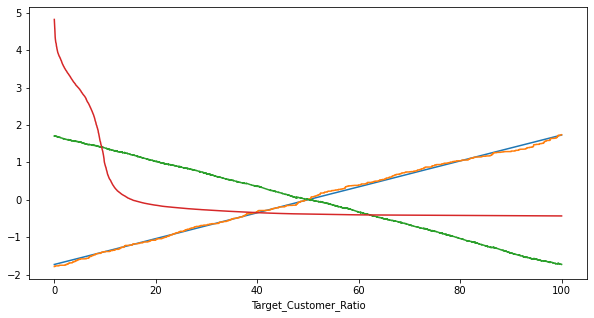

```python
from sklearn.preprocessing import scale

fig1 = plt.figure(figsize = (10, 5))
sns.lineplot(dfsimu['Target_Customer_Ratio'], scale(dfsimu['Retain_Cost']))
sns.lineplot(dfsimu['Target_Customer_Ratio'], scale(dfsimu['Retain_Revenue']))
sns.lineplot(dfsimu['Target_Customer_Ratio'], scale(dfsimu['Retain_Net_Profit']))
sns.lineplot(dfsimu['Target_Customer_Ratio'], scale(dfsimu['Churn_Scores']))
plt.show()
```

```python
print(dfsimu.Sales_Target_Customer.max(), dfsimu.Retain_Net_Profit.max())
```

```
0.1078167115902965 67.75301162479184
```

```python
dfsimu[dfsimu.Target_Customer_Ratio < 13].Customer_ID
```

```
0       K299110
1       K381620
2       K153050
3       K285080
4       K401570
         ...
2406    K111900
2407    K157920
2408    K267770
2409    K406750
2410    K185780
Name: Customer_ID, Length: 2411, dtype: object
```